# CO 3 — Connected Vehicles and Distributed Autonomous Systems

## A textbook-style notebook with architectures, worked problems and executable laboratories

**Coverage:** VANETs · Internet of Vehicles · Edge · Fog · Cloud · Middleware · Synchronization · Distributed consistency.

**Level:** senior undergraduate / introductory postgraduate. **Source check date:** 24 September 2026. The notebook teaches concepts using explicitly identified editions and foundational papers; a cited older standard is not claimed to be the latest revision. No particular university syllabus or examination paper was supplied, so this is comprehensive coverage of the eight requested topics, not a claim of complete coverage of an unspecified syllabus.

### How to study this book

Read Chapters 1–2 for the communication context, Chapters 3–5 for computation placement, Chapter 6 for software integration, and Chapters 7–8 for the meaning of time and shared state. Work through the numerical examples before running their verification cells. Finish with the integrated case study, examination answers and practice problems. Each chapter develops definitions, mechanisms, architectural choices, failure modes and applications.

**Evidence convention.** Linked references support standards, protocol properties and established results. All diagrams, worked calculations, workloads, budgets and design case studies are original teaching constructions. They are not field measurements, certified safety designs, or claims about actual deployments. A calculation is valid under its stated model; its result is not a universal performance guarantee. Source access failures are disclosed in the bibliography rather than treated as verified full-text evidence.

**Notebook operation.** Saved figures and laboratory outputs are embedded. Read them without running code, or select **Run All** in Jupyter using Python 3 with NumPy and Matplotlib. The notebook does not need cloud credentials, a radio simulator, ROS, a broker or Internet access to run. Its simplified experiments demonstrate mechanisms; they do not implement complete communication standards.

## Contents

- Chapter 1 — Vehicular Ad Hoc Networks (VANETs)
- Chapter 2 — Internet of Vehicles (IoV)
- Chapter 3 — Edge Computing
- Chapter 4 — Fog Computing
- Chapter 5 — Cloud-Based Architectures
- Chapter 6 — Middleware Frameworks
- Chapter 7 — Data Synchronization
- Chapter 8 — Data Consistency in Distributed Autonomous Systems
- Worked numerical problems — all eight topics
- Executable laboratories
- Integrated design case — a connected autonomous campus shuttle
- Documented research case — Spanner and the meaning of time
- Examination preparation — questions with developed answers
- Practice problems and answer guide
- Formula sheet and common misconceptions
- Glossary
- References and verification boundaries

## Learning map and prerequisites

By the end, you should be able to:

1. Draw a vehicular communication architecture and distinguish radio access, routing and application semantics.
2. Explain why IoV involves identity, services and data management in addition to VANET connectivity.
3. Calculate a task's local and remote execution time, then decide whether offloading is feasible.
4. Compare edge, fog and cloud without treating them as mutually exclusive products.
5. Choose communication middleware using delivery, freshness, compatibility and operational requirements.
6. Calculate clock offset, clock drift, logical ordering, data age and replication backlog.
7. Select a consistency contract for a particular object and explain its partition behavior.
8. Critique an end-to-end design using explicit assumptions, invariants and measurable acceptance criteria.

Prerequisites are basic networking, processes, queues, probability and elementary algebra. A **process** executes instructions; a **node** hosts one or more processes; a **replica** stores a copy of some state. A node can fail while others continue, making a distributed system different from one large program. A delayed reply does not by itself distinguish a failed server from a slow network. The Raft paper makes timing and failure assumptions explicit for replicated state machines. [S12](https://raft.github.io/raft.pdf)

### Four separate questions

| Question | Topic that answers it | Example |
| --- | --- | --- |
| Who can communicate? | VANET / V2X | A vehicle receives a roadside warning |
| Where does work execute? | Edge / fog / cloud | Roadside processing estimates queue length |
| How do components exchange information? | Middleware | A typed sensor topic feeds a fusion node |
| What does shared information mean? | Synchronization / consistency | A reservation cannot be granted twice |

Do not substitute one answer for another. A fast radio does not define database ordering. A replicated database does not establish that a camera observation is still fresh. A reliable message channel does not prove that an actuator executed a command once.

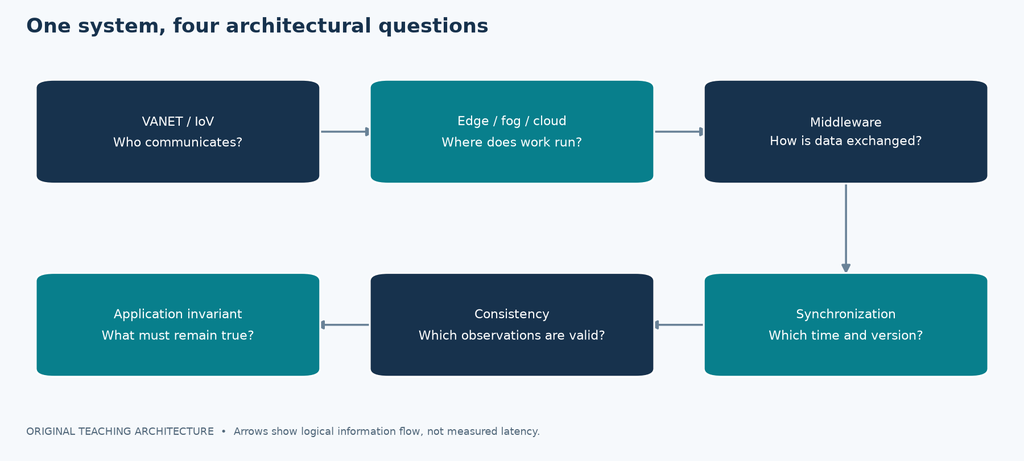

*Figure: One system, four architectural questions. Original conceptual diagram; see the surrounding text for assumptions.*

## Mathematical foundations and notation

This book uses decimal network and storage units unless stated otherwise: 1 kbit = 1,000 bits, 1 Mbit = 1,000,000 bits, 1 MB = 1,000,000 bytes; 1 MiB = 1,048,576 bytes. Multiply bytes by eight before dividing by a bit rate. A delay in milliseconds must be divided by 1,000 before multiplication by a speed in metres per second.

| Symbol | Meaning | Unit |
| --- | --- | --- |
| $L,B$ | Message length / task input | bits |
| $R$ | Useful transmission rate | bit/s |
| $C$ | Required CPU cycles | cycles |
| $f$ | Effective processing rate | cycles/s |
| $\lambda,\mu$ | Arrival / service rate | jobs/s |
| $D$ | End-to-end deadline | s |
| $\Delta$ | Data age or a stated time interval | s |
| $\rho$ | Utilization, or drift when explicitly specified | dimensionless |
| $N,R_q,W_q$ | Replica count, read quorum, write quorum | counts |

### Delay is a sum, not a radio label

For a sequential path, define

$$T_{e2e}=T_{sense}+T_{encode}+T_{queue}+T_{access}+T_{tx}+T_{prop}+T_{compute}+T_{return}+T_{actuate}.$$

The transmission component is $T_{tx}=L/R$. Propagation is $T_{prop}=d/v_p$, where $v_p$ is the propagation speed in the medium. Processing includes serialization, verification and application computation if those costs are not counted elsewhere. In a parallel pipeline, use the dependency graph rather than adding stages that overlap. These are accounting identities for the chosen model, not estimates supplied by a standard.

**Mean versus bound.** A 15 ms mean does not establish a 20 ms maximum. State whether a number is a mean, percentile, observed maximum or analytically justified upper bound. Percentiles of stages cannot generally be added to obtain the same percentile of total delay. The examples that add delays use deterministic assumptions or explicitly add expected values.

**Deadline versus freshness.** A response can arrive quickly while containing an old observation. Measure response latency from request to reply and data age from observation generation to use. Both may matter.

### Reliability and queueing models used here

Under an explicit independence assumption, a path of $h$ links with delivery probabilities $p_i$ has one-attempt success $P=\prod_i p_i$. Shared interference can violate independence. With independent repeated attempts of success probability $p$, success within $k$ attempts is $1-(1-p)^k$; retries consume time and capacity.

For an ideal M/M/1 queue, Poisson arrivals, independent exponential service, one server, an unlimited queue and $\lambda<\mu$ give $W=1/(\mu-\lambda)$ and $W_q=\lambda/[\mu(\mu-\lambda)]$. These equations follow from the geometric stationary distribution with utilization $\rho=\lambda/\mu$, mean population $L=\rho/(1-\rho)$, and $W=L/\lambda$. They are teaching models, not worst-case guarantees for an actual GPU service. Later numericals show every substitution.

### A disciplined design method

Begin with the required outcome and the invariant that must never be violated. Identify data sources, uncertainty, deadlines and ownership. Draw the normal path, then redraw it with a failed link. Calculate resources under the stated workload. Assign consistency and delivery behavior to each data object. Finally, specify a test that could disprove the design. The opportunity cost of an elaborate distributed architecture is more components to configure, observe and recover; use extra layers only when they solve an explicit requirement.

# Chapter 1 — Vehicular Ad Hoc Networks (VANETs)

## Concept, scope and components

A VANET is a vehicular instance of an ad hoc network: vehicles communicate over wireless links, potentially with roadside infrastructure, while connectivity changes as participants move. In this notebook, the term describes the networking problem rather than a single compulsory protocol stack. Cooperative ITS standards describe vehicle-to-vehicle and vehicle-to-roadside information exchange. [S1](https://www.etsi.org/technical-groups/its/)

An **on-board unit (OBU)** is the vehicle's communication endpoint in our reference architecture. A **roadside unit (RSU)** is a fixed roadside endpoint. A vehicle also contains sensing, localization, compute and control subsystems. The RSU is not automatically an edge server: it may only forward messages, or it may connect to a separate compute host. Keeping these roles separate prevents a diagram from implying processing capacity that was never specified.

### Reference architecture and packet journey

Our hypothetical vehicle detects an obstacle. Its application creates an event containing observation time, location, uncertainty and an expiry. A security layer authenticates the message. Radio access transmits it. A receiving vehicle checks identity, freshness and relevance before passing it to a decision module. A distant fleet dashboard may receive an aggregated copy through an RSU and backhaul. The dashboard path need not be the immediate local warning path.

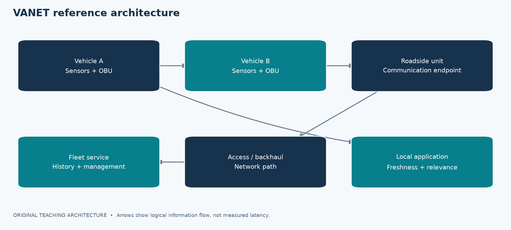

*Figure: VANET reference architecture. Original conceptual diagram; see the surrounding text for assumptions.*

**Reading the architecture:** V2V is a peer communication relation; V2I involves infrastructure; V2N reaches a network service. V2X is the umbrella terminology. An arrow identifies information flow, not guaranteed coverage or a specified delay. The same application can involve several paths, and duplicate observations need a common event identity to avoid repeated effects.

## Why mobility changes the problem

Consider two cars moving in opposite directions through a limited coverage area. Their useful contact duration can be short even if the instantaneous link is fast. A route discovered now may disappear before a large object finishes transferring. At an intersection, buildings may obstruct links; on an empty road there may be no relay; in dense traffic many transmitters may compete. These are conditions to explore in a workload model, not universal numerical claims about every road.

Use a graph $G(t)=(V(t),E(t))$ to make this precise. A vertex is a participant, and an edge means the assumed communication condition is satisfied at time $t$. A path in $G(t_0)$ is not necessarily available throughout $[t_0,t_0+T]$. Thus route selection should consider the lifetime required by the application, not only the hop count. A useful simulation should expose how it defines an edge: range threshold, measured packet reception, or a channel model.

## Communication modes and access technologies

ETSI CAMs carry cooperative awareness information; DENMs concern events such as road hazards. Their message semantics are distinct from the radio carrying them. The cited CAM Release 2 specification is TS 103 900 V2.1.1 (2023-11), while the older ETSI announcement explains CAM/DENM roles. [S2](https://www.etsi.org/deliver/etsi_ts/103900_103999/103900/02.01.01_60/ts_103900v020101p.pdf), [S3](https://www.etsi.org/newsroom/news/851-2014-12-press-etsi-publishes-european-standards-for-intelligent-transport-systems/)

The 5G NR V2X tutorial describes Release 16 sidelink, resource allocation and V2N architecture. PC5 identifies direct sidelink communication; Uu is the cellular access interface. Direct communication is not equivalent to routing every packet through a remote cloud. LTE-V2X and NR-V2X are different radio systems; do not assume that using the V2X label alone establishes interoperability. [S4](https://arxiv.org/abs/2102.04538)

| Design dimension | Direct local exchange | Infrastructure / network path |
| --- | --- | --- |
| Reach in our model | Nearby reachable participants | Service reached through access and backhaul |
| Dependency to investigate | Peer visibility and channel conditions | Access, backhaul and service health |
| Candidate workload | Local event or awareness | Fleet data, maps and broad coordination |
| Main test | Delivery within contact and expiry | Delay and continuity during mobility |

This table is a design comparison, not a claim that one technology is always faster. Congestion, scheduling, payload size, coverage and implementation determine results. Spectrum permissions and deployment rules are jurisdiction-specific; this book does not assume that a European protocol profile is automatically authorized in India.

## Routing, forwarding and dissemination

Routing selects a path; forwarding sends a particular packet to its next destination. Dissemination may aim at all relevant receivers rather than one host. Do not confuse radio resource selection with multihop route computation.

**Topology-based example: AODV.** AODV discovers routes on demand using route requests and route replies; destination sequence numbers help manage freshness, and route errors report broken paths. It is specified as an Experimental RFC rather than a universal mandatory VANET protocol. In a moving network, route discovery traffic and repair delay must be included in the experiment. [S5](https://www.rfc-editor.org/rfc/rfc3561)

**Geographic teaching policy.** Suppose every relay knows its position and the destination coordinates. Select a reachable neighbor that reduces the remaining geometric distance. This avoids retaining an entire end-to-end route in our toy model, but it can get stuck at a local minimum: no neighbor is closer even though a detour exists. A production geographic protocol needs explicit handling for such conditions and position error. The policy described here is an illustrative greedy rule, not a complete named standard.

**Geocast teaching policy.** Define a geographic region, a message expiry and a forwarding budget. A relay forwards only if it contributes coverage and has not recently forwarded the same event. This design targets relevance rather than an arbitrary global broadcast. It requires assumptions about location accuracy and duplicate detection.

**Store–carry–forward teaching policy.** If no next hop is available, keep a delay-tolerant item until a new contact appears. Carrying a log until an RSU is encountered may be acceptable; carrying a braking warning for minutes is not. Buffer limits, expiry and priority are essential.

### A dissemination flowchart

```
Receive event
    |
Authenticate and decode -- failure --> reject and record reason
    |
Check event ID + expiry -- duplicate / expired --> suppress
    |
Check geographic relevance -- irrelevant --> stop local delivery
    |
Deliver to application
    |
Forwarding useful and budget remains? -- no --> finish
    | yes
Schedule bounded forwarding --> transmit --> record event ID
```

This original policy exposes why “flood everything” has a cost. More relays may increase coverage but also add channel load, duplicate work and verification load. A forwarding optimization should report both the benefit and the overhead.

## Performance, threats and measurement

Define packet delivery ratio as successfully received intended packets divided by packets expected at those receivers under the stated counting convention. For broadcast, explicitly define receiver eligibility; counting only receivers that happened to hear something biases the result. Report end-to-end delay, inter-reception gaps, deadline misses, useful coverage, channel load and routing overhead. Average throughput alone does not characterize a warning service.

Our threat model includes spoofed messages, replayed old events, compromised legitimate senders and denial of service. A signature can establish a cryptographic origin under a trust model; it does not prove that a reported obstacle physically exists. Proposed defenses therefore combine authentication, expiry, rate limits and plausibility checking. These are design requirements for the teaching case, not a complete security certification.

### Case study — warning around a blind bend

**Hypothetical requirement:** deliver a locally relevant obstacle event before its assigned expiry, while cars outside the affected direction are not unnecessarily alerted. **Architecture:** source OBU → reachable relay or RSU → approaching vehicles; a separate asynchronous copy goes to the operator dashboard. **State:** event ID, road segment, direction, observation time, confidence and expiry.

**Failure experiment:** disconnect the RSU, then introduce a long gap between vehicles. The design must report loss of communication coverage rather than silently presenting an old message as current. A local sensing function remains responsible for its own operating assumptions. **Trade-off:** repeated warning transmission may improve reception probability but competes with awareness traffic. **Evidence required before deployment:** measured reception by distance and obstruction, end-to-end age, false-event behavior and congestion response. No actual deployment performance is claimed here.

### Chapter checkpoint

Explain why an RSU is not necessarily a compute server; why route discovery overhead matters; why PDR must define its denominator; and why a valid signature does not establish environmental truth. A strong long answer includes the architecture, message path, mobility model, forwarding policy, metrics and failure behavior.

# Chapter 2 — Internet of Vehicles (IoV)

## From connectivity to a service ecosystem

For this book, **IoV** denotes the wider connected-vehicle service ecosystem: vehicles, roadside systems, communication networks, computing platforms, data services and operational management. This is a working architectural definition, not a claim that one universally mandated IoV layer model exists. ETSI cooperative ITS and MEC provide concrete standardized building blocks, but our five-layer diagram is a teaching organization. [S1](https://www.etsi.org/technical-groups/its/), [S8](https://www.etsi.org/technical-groups/mec/)

The useful distinction is scope. A VANET discussion asks how moving participants exchange packets. An IoV discussion also asks how devices are enrolled, which service owns a record, how data is retained, how applications are updated and how failures are observed. A vehicle may use ad hoc communication as one part of an IoV system. It may also use a wide-area connection without participating in a multihop VANET.

## A five-layer teaching architecture

1. **Perception and actuation:** cameras, vehicle signals, position estimates and control interfaces produce or consume physical-world information.
2. **Connectivity:** local links and network access transport messages between authenticated endpoints.
3. **Compute and storage:** on-board processors, roadside servers, regional services and cloud resources host workloads.
4. **Platform services:** identity, discovery, schemas, event distribution, storage APIs, observability and update management support applications.
5. **Applications:** traffic information, fleet operations, maintenance, map distribution and cooperative services use these capabilities.

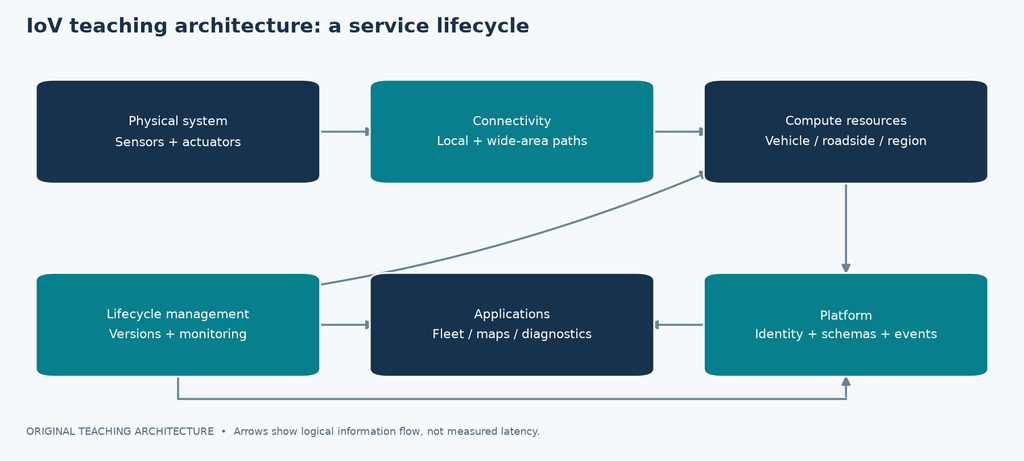

*Figure: IoV teaching architecture: a service lifecycle. Original conceptual diagram; see the surrounding text for assumptions.*

Security, time quality and lifecycle management cross every layer. A well-designed application cannot repair a bad physical timestamp after the original observation has been discarded. Likewise, encrypted transport does not fix a semantic mismatch between kilometres per hour and metres per second.

### The data contract

Our example event envelope is:

```
event_id, producer_id, boot_id, sequence_number
schema_version, event_type, observed_at, expires_at, time_uncertainty
coordinate_frame, position, position_uncertainty
payload, provenance, authentication_context
```

These fields solve different problems. `event_id` supports duplicate detection. A `boot_id` avoids treating a sequence-number reset after reboot as an old packet. `schema_version` identifies how to interpret bytes. `observed_at` describes the world at observation time, while a separately recorded ingestion timestamp supports operations analysis. `coordinate_frame` prevents fusion of quantities expressed in different frames. Provenance records how a value was produced. The exact schema is original to this example and is not presented as a CAM schema.

### Control plane and data plane

In the reference design, the **data plane** transports observations, results and application requests. The **control plane** configures identities, access rules, service placement and routing policy. This separation helps reason about outages. Losing contact with a management service need not stop every existing local data flow, provided policy explicitly permits continued operation for a bounded period. Continuing indefinitely without renewed authorization is a different choice and must be designed, not accidentally inherited.

## Service lifecycle and system behavior

### Enrollment, discovery and authentication

Our device first obtains an identity through an administrative enrollment process. It then discovers permitted service endpoints, authenticates the connection, checks schema compatibility and starts its data flow. Discovery answers “where is the service?”; authentication answers “who is this endpoint?”; authorization answers “what may it do?”. Combining these into one vague “connection” box hides failure cases.

A practical teaching failure is an authenticated but obsolete producer sending an old schema. The receiver should reject it or invoke an explicitly supported conversion. Silently treating an absent field as zero can turn “unknown speed” into “stationary vehicle.” Preserve unknown values as unknown.

### Digital representation and model lifecycle

For our fleet example, a digital representation contains current state estimates, configuration and maintenance history. It is not the physical vehicle, and its freshness depends on synchronization. A dashboard must distinguish “last reported battery level” from “current battery level.” The same distinction applies to a map cache and a model registry.

A proposed model update path is **train → evaluate → package → authenticate → stage → activate → monitor → retain rollback option**. The instructional reason for staging is that a transfer interrupted halfway must not leave an application reading half of one model and half of another. A manifest identifies compatible software, data schema and model versions. This is a design pattern for the example, not a claim about any manufacturer's update implementation.

## Workload classification

| Workload in the teaching fleet | Dominant concern | Proposed placement | Proposed outage behavior |
| --- | --- | --- | --- |
| Immediate local control | Timing and local validity | On-board | Operate only within local capability |
| Intersection observation fusion | Freshness and location relevance | Roadside edge | Expire unavailable remote observations |
| Corridor traffic estimate | Multi-intersection aggregation | Regional fog | Mark reduced spatial coverage |
| Historical maintenance analysis | Durable history and scale | Cloud | Buffer locally within capacity |
| Software distribution | Integrity and version coherence | Cloud plus local caches | Keep last compatible active version |

These are choices to justify against actual requirements, not mandatory placements. A cloud service can participate in an architecture without being in every immediate control path. Conversely, an on-board computer can be overloaded or fail; local placement alone does not establish safety.

### Case study — a mixed-connectivity bus fleet

**Hypothetical system:** buses record energy use and diagnostic events, exchange selected road-condition information and upload maintenance logs when connectivity permits. Each bus keeps an append-only outbox. A depot gateway reconciles uploaded event IDs and forwards accepted records to a central history store. A regional service produces route-level aggregates.

**Design reasoning:** diagnostic history tolerates delayed upload, so temporary disconnection need not lose records if the buffer is adequately provisioned. A road-condition observation has an expiry and should not be replayed as a fresh alert during a later depot upload. Thus one transport connection carries data with different semantic lifetimes; the application must preserve the difference.

**Failure trace:** the bus uploads an event; the server stores it; the acknowledgment is lost; the bus retries. Without deduplication, the dashboard counts two events. With an atomic event-ID check and insertion, the second submission returns the existing result. If the deduplication record expires before retry is possible, the guarantee no longer holds. Specify the retention horizon.

**Opportunity cost:** retaining every raw sample indefinitely increases storage, transmission and privacy exposure. An alternative is local summarization with a bounded diagnostic window, but it may remove evidence needed for later investigation. State retention objectives before choosing compression or deletion policies.

### VANET versus IoV — examination comparison

| Aspect | VANET focus | IoV focus in this book |
| --- | --- | --- |
| Main question | Communication under vehicle mobility | End-to-end connected service operation |
| Core entities | Vehicles and roadside communication nodes | Vehicles, infrastructure, platforms and operators |
| Common analysis | Connectivity, forwarding, reception, delay | Lifecycle, data contracts, computing and shared state |
| Relationship | A networking component | An encompassing service architecture |

**Checkpoint:** draw one packet path and one management path; explain observation time versus upload time; identify a service that can buffer and one that must expire stale data; and explain why adding an Internet connection does not automatically create a complete IoV platform.

# Chapter 3 — Edge Computing

## Meaning and motivation

Edge computing places processing near the data source or the point where information is consumed. “Near” must be defined operationally: on the device, in a roadside cabinet, on a campus gateway or at an access-network site. ETSI MEC standardizes an environment for applications and services at network edges; it is a specific standards ecosystem within the broader edge concept. [S8](https://www.etsi.org/technical-groups/mec/)

The central design question is whether placing work closer reduces the **whole application path** enough to justify the added distributed infrastructure. Sending a large raw image to a fast server may take longer than computing a smaller result locally. A lightly loaded remote accelerator may outperform an overloaded nearby processor. Distance is only one input.

## Reference architecture

Our edge host contains an ingress gateway, admission controller, bounded queue, application workers, local data cache and monitoring agent. An orchestrator deploys compatible application versions and assigns resources. The radio endpoint and edge host are distinct boxes even when installed together. That distinction allows us to account for transport between them.

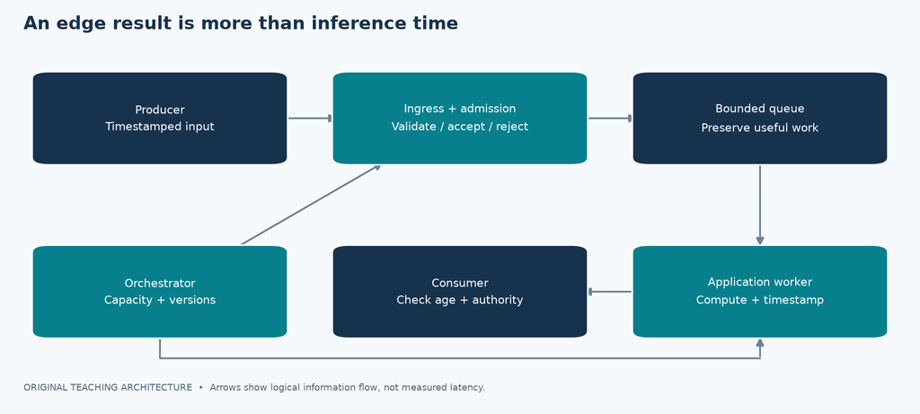

*Figure: An edge result is more than inference time. Original conceptual diagram; see the surrounding text for assumptions.*

**Data path:** source → input validation → admission → queue → worker → timestamped result → consumer. **Management path:** configuration and version updates reach the host separately. **Failure path:** unavailable or expired remote results cause an application-defined fallback. This is an original architecture, not a reproduction of the complete ETSI MEC reference model.

## Task offloading model

Let an independent task require $C$ cycles, accept $B_u$ input bits and return $B_d$ output bits. Let local processing rate be $f_l$, edge rate $f_e$, uplink/downlink useful rates $R_u,R_d$, and fixed non-transmission overhead $T_o$. Then:

$$T_l=C/f_l,$$ $$T_e=B_u/R_u+T_o+T_q+C/f_e+B_d/R_d.$$

These equations assume sequential upload, processing and download, no overlap, constant effective rates, and a queue delay supplied separately. If the local task also queues, add its queue delay. If input is already cached remotely, adjust $B_u$ rather than pretending every run retransmits it.

The decision “offload when $T_e<T_l$” is incomplete if a deadline $D$ exists: require $T_e\le D$ too. The selected server may need a compatible accelerator, enough memory, authorization to process the data, and contact duration exceeding the transaction time. Introduce a feasibility filter before optimization.

For an uplink threshold, collect all non-upload remote costs into $T_r$. When $T_l>T_r$, offloading is faster if

$$R_u>\frac{B_u}{T_l-T_r}.$$

If $T_l\le T_r$, no finite uplink rate makes this sequential model faster than local execution. This is an important interpretation: adding bandwidth cannot fix an excessive compute or fixed-overhead cost.

### Energy model

For the teaching model, $E_l=P_lT_l$ and $E_e=P_{tx}T_{upload}+P_{rx}T_{download}+P_{idle}T_{wait}$. This accounts for the device's energy, not the whole infrastructure's energy. It omits connection setup, tail energy, thermal effects and background workloads. A design claiming global energy savings must include server and network consumption as well. Choose the boundary before reporting a percentage.

## Scheduling, queues and admission

A server running every received task may create an unbounded backlog. Our admission rule estimates whether a task can finish before expiry; if not, it rejects, redirects or degrades it according to application policy. For a latest-state stream, replacing an obsolete queued sample can be more useful than eventually processing all historical samples. For accounting events, discarding queued records would change the required semantics.

**FIFO example:** jobs execute in arrival order. It is simple but a large job can delay a small urgent one. **Earliest-deadline-first teaching policy:** choose the ready job with the nearest deadline; this still needs a feasible workload and a defined preemption model. **Reservation approach:** allocate capacity to a critical class and admit other work only within remaining resources. These are alternative policies in our model, not a claim that choosing an acronym guarantees real-time operation.

The M/M/1 example later demonstrates that mean response time grows rapidly near saturation. A deterministic safety argument instead requires bounds on arrivals, execution, blocking and interference. A mean queue calculation cannot be used as a worst-case proof.

## Mobility and service continuity

Suppose a vehicle moves from edge A's coverage to edge B's. There are at least three distinct transitions: radio access changes, traffic routing changes, and application state moves or becomes accessible elsewhere. They may complete at different times. An application-level handover contract should define the state version, active owner, duplicate suppression and maximum permitted disruption.

A proposed handover sequence is: predict destination → prefetch immutable assets → copy a state checkpoint → transfer remaining updates → establish new ownership epoch → direct new work to B → retire A's authority. The epoch matters because a delayed result from A should not overwrite newer work from B. Copying bytes without transferring authority can create two active writers.

### Case study — roadside object fusion

**Hypothetical goal:** fuse selected observations from several roadside sensors and publish a time-bounded scene estimate. **Architecture:** each producer timestamps observations; the edge verifies schema and coordinate frames; the fusion window admits only sufficiently fresh and aligned data; the result includes coverage and uncertainty.

**Blank spot to avoid:** reporting only inference time. Upload, verification, alignment, queueing and result delivery all contribute. A 5 ms inference operation could sit behind a 200 ms queue in a badly provisioned system. **Failure test:** stop one producer and check that the result changes its coverage indicator instead of treating the last sample as permanently valid.

**Trade-off:** raw inputs permit richer fusion but increase traffic. Sending object lists reduces traffic but commits the receiving service to the upstream detector's errors and schema. The better choice depends on the required information, not a general rule that more raw data is always better.

### Advantages, costs and checkpoint

Potential gains in the model are reduced transfer distance, local aggregation and operation during some backhaul outages. Costs include distributed maintenance, limited host capacity, mobility coordination and a larger set of locations to secure. Verify gains using equivalent workloads and full paths.

Explain the offloading inequality, draw the admission path, distinguish migration from replication, and identify why contact duration and result expiry belong in a placement decision.

# Chapter 4 — Fog Computing

## Concept and relationship to edge

NIST SP 500-325 describes fog as a distributed and federated computing model that places resources within the network between end devices and traditional cloud systems. Its conceptual model addresses heterogeneity and the management of IoT data. [S6](https://csrc.nist.gov/pubs/sp/500/325/final)

In this book, **edge** emphasizes processing close to an endpoint, while **fog** emphasizes coordination across distributed intermediate resources. Terminology overlaps; a roadside server may be called an edge node and also be part of a fog system. Do not present fog as a compulsory extra box in every architecture or assume that the labels impose exact geographic distances.

## Hierarchical and federated teaching architectures

Our hierarchy contains device-level processing, intersection nodes, a corridor aggregator and a regional platform connected to the cloud. Lower tiers process local observations; higher tiers combine broader context. A horizontal alternative allows neighboring nodes to exchange selected results directly. A hierarchy simplifies ownership, while horizontal sharing may avoid an unnecessary upstream round trip; it also adds peer relationships and reconciliation work.

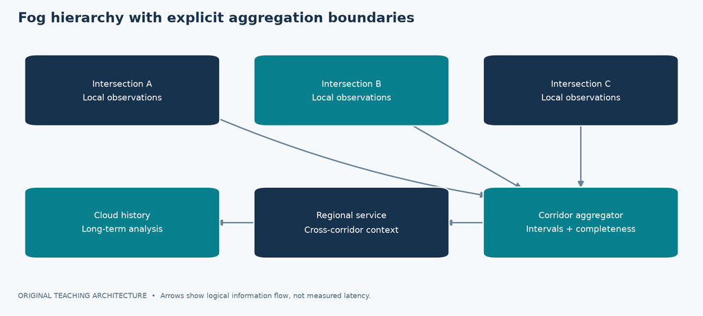

*Figure: Fog hierarchy with explicit aggregation boundaries. Original conceptual diagram; see the surrounding text for assumptions.*

### Functional decomposition

For a hypothetical corridor service, local nodes count vehicles per interval, regional nodes combine counts and the cloud retains historical trends. The count boundary matters. If two sensors observe the same vehicle, summing their counts may double-count it. Distinct observation counts and distinct vehicle counts are different measures. Define whether the aggregate uses deduplicated identifiers, non-overlapping zones or merely reports sensor observations.

**Filtering** removes unwanted records under a stated predicate. **Aggregation** combines values, such as per-minute counts. **Compression** changes representation and may be lossless or lossy. These operations should not be conflated. Discarding data can reduce bytes but may also remove rare-event evidence.

## Placement across several tiers

Represent an application as a directed acyclic graph with vertices as tasks and edges as transferred data. A placement maps each task to a host. The total path delay includes compute and communication along dependent stages. If two branches run concurrently and a join waits for both, the branch contribution is the larger completion time, not their sum.

A teaching optimization is:

$$\min_x\left(\alpha T(x)+\beta E(x)+\gamma K(x)\right)$$

subject to deadline, capacity, data-location and availability requirements. Here $K$ is a declared cost measure and weights must have compatible normalization. Adding milliseconds directly to joules without scaling produces an uninterpretable objective. Multi-objective reporting can be clearer than hiding priorities in weights.

### Capacity and backpressure

When an upstream link slows, intermediate queues grow. A policy can slow producers, drop obsolete state, compress data, buffer durable events or reject work. Each has different semantics. A hazard event should not be silently merged into a daily statistic if a consumer expects its individual identity. A visual dashboard may tolerate downsampling that an audit log cannot.

## Federation, failure domains and operations

Our federation consists of independently managed roadside and regional resources. It requires agreements about accepted identities, data schemas, resource limits and responsibility for failures. The operational problem is as important as workload placement: who renews certificates, deploys a compatible version and restores a failed disk?

A **failure domain** is a set of components that may fail together under an identified cause. Two fog nodes in the same cabinet may share power and backhaul. Replicating across them protects against some process failures but not that cabinet's loss. Independence must be justified before multiplying availability figures.

**State ownership proposal:** immutable observations may be copied widely; a corridor's active configuration has an explicit owner or coordinated update protocol; local control retains a defined authority boundary. This separates useful data sharing from accidental multiple-writer control.

### Service migration versus warm replication

Migration moves an application's execution or active role. Replication maintains additional copies. Warm replication may shorten recovery because some state is already present, but it consumes capacity continuously and introduces lag. A checkpoint of size $S$ needs at least $S/R$ seconds to transmit over an effective rate $R$, before setup or replay costs. If state changes faster than it can be copied, a naive pre-copy process may fail to catch up.

Consider a teaching migration with dirty-state production rate $d$ bits/s and transfer rate $R$. If each copying round creates a new dirty fraction $d/R$, the ideal geometric series converges only when $d/R<1$. Real systems have finite stopping criteria and workload variation, but this elementary model explains why bandwidth alone is not enough: the rate of change also matters.

### Case study — corridor traffic aggregation

**Hypothetical requirement:** publish a corridor estimate with explicit spatial coverage, while preserving short-term local service during loss of the central connection. **Design:** each intersection emits interval summaries with unique interval IDs and source IDs. The regional node rejects duplicates, records missing intervals and produces a coverage-aware aggregate. The cloud receives historical copies.

**Failure trace:** intersection C becomes disconnected. A naive regional sum decreases and falsely suggests traffic has improved. Our result instead reports “two of three sources present” and avoids interpreting missing data as zero. When C reconnects, its historical interval records update the historical store rather than overwrite the current interval.

**Acceptance test:** replay intervals in random order with duplicates and omissions. Verify that duplicate delivery does not inflate totals, missing sources are visible, and late data follows an explicit correction policy. **Opportunity cost:** a regional tier introduces another operational dependency; if all requirements can be met with local nodes and a central service, adding fog may be unnecessary.

### Edge, fog and cloud comparison

| Dimension | Edge emphasis | Fog emphasis | Cloud emphasis |
| --- | --- | --- | --- |
| Organizing idea | Proximity to source/use | Distributed intermediate coordination | Shared elastic service resources |
| Example in this book | Intersection fusion | Corridor aggregation | Fleet history and batch analysis |
| Resource question | Can this host meet the task budget? | How should tiers share work? | How should a shared service scale? |
| Failure question | What if this local node fails? | What if tiers are partitioned? | What if the service/path is unavailable? |

These columns describe architectural emphases rather than disjoint technologies. **Checkpoint:** explain what an aggregation loses, why missing is not zero, how a failure domain changes replication value, and when an intermediate tier earns its complexity.

# Chapter 5 — Cloud-Based Architectures

## Cloud model and service boundaries

NIST SP 800-145 identifies five cloud characteristics: on-demand self-service, broad network access, resource pooling, rapid elasticity and measured service. It distinguishes IaaS, PaaS and SaaS, and public, private, community and hybrid deployment models. These service and deployment categories answer different questions. [S7](https://csrc.nist.gov/pubs/sp/800/145/final)

For example, **IaaS** gives the consumer infrastructure on which to deploy software; **PaaS** provides an application platform; **SaaS** exposes an application service. A private cloud can provide IaaS, and a hybrid architecture can combine several service models. Owning one remotely accessible server does not, by itself, establish all the NIST cloud characteristics.

## Reference fleet backend

Our reference architecture contains an authenticated ingestion API, durable event log, stream processor, historical object store, operational database, analytics jobs and an application API. A separate model/configuration distribution path returns versioned artifacts to vehicles or caches. This decomposition is a teaching design rather than a description of a particular vendor product.

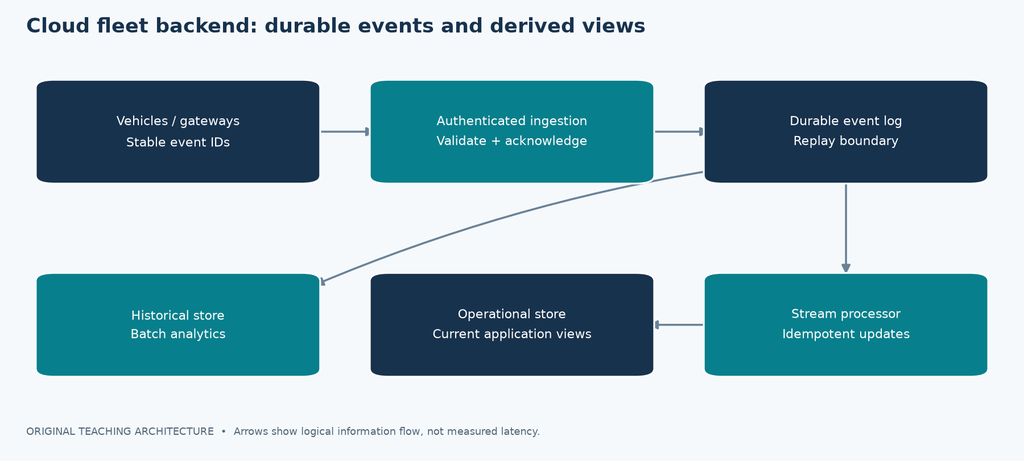

*Figure: Cloud fleet backend: durable events and derived views. Original conceptual diagram; see the surrounding text for assumptions.*

The ingestion acknowledgment must have a stated meaning: received in memory, appended durably, replicated, or fully processed. These are different completion points. A client cannot infer durable storage merely from a successful TCP transmission. In our example, an acknowledgment is sent after the event ID and record are durably committed within the defined storage boundary.

### Batch and stream paths

A batch job processes a finite dataset, such as yesterday's maintenance records. A streaming job continuously processes arriving events. A streaming dashboard may still be delayed by upload gaps or out-of-order arrivals. “Real time” should therefore specify a latency and freshness objective rather than be used as a marketing adjective.

For our traffic estimate, event time identifies the observation interval, while processing time identifies when the platform handles it. An event-time window can be revised by late observations if the application permits it. The design must define how users learn that a previously published result changed.

### Stateful versus stateless services

A stateless API worker can often be replaced without transferring an application session, provided the durable state is elsewhere. A stateful partition owner may need checkpoint recovery and replay. Externalizing state does not remove state management; it moves it to another component. The resulting database can become a bottleneck or failure dependency unless it is included in the capacity model.

Partitioning assigns different keys or ranges to different owners; replication copies the same data. Partitioning can distribute load, but a popular key may still overload one partition. Replication can improve fault tolerance or read capacity under a chosen protocol; it does not automatically remove write coordination costs. These distinctions drive the toy designs in Chapter 8.

## Scalability, storage and resilience

### Capacity worksheet

For $n$ vehicles generating $r$ records/s of $b$ bytes, raw payload ingestion is $nrb$ bytes/s. Retaining that payload for $t$ seconds needs $nrbt$ bytes before indexing, replication, metadata or compression. If the workload is bursty, average ingress does not dimension the peak queue. If the result is quoted as storage cost, actual service prices and charging units are additionally required; this book uses no live pricing assumptions.

The storage numerical later begins with 1,000 vehicles and derives daily bytes step by step. It separates raw payload from a hypothetical three-copy storage multiplier. Calling the multiplied number “raw input” would conceal the accounting boundary.

### Recovery terms

For the teaching architecture, **RPO** is the target maximum data loss measured as a time interval, and **RTO** is the target time to restore service. They are requirements to test, not properties acquired by selecting a cloud provider. Backups support recovery from certain corruption or deletion scenarios; a live replica may promptly replicate the same bad deletion. Replication and backups solve overlapping but different failure problems.

A restore exercise should identify the backup, recover into a controlled target, replay appropriate logs and verify application invariants. A green infrastructure health indicator is not evidence that every expected event was restored. Count records and reconcile identities against the declared recovery boundary.

### Availability accounting

For sequential dependencies assumed independent, $A_{system}=\prod_i A_i$. This is a model, and common power, network or software dependencies can invalidate independence. A 99.9% target over a specified 30-day interval corresponds arithmetically to $0.001\times30\times24\times60=43.2$ minutes. The target does not specify whether downtime occurs in one long outage or many short ones; these patterns can have different application consequences.

### Case study — fleet maintenance analytics

**Hypothetical workload:** vehicles upload diagnostic events with occasional gaps. The backend stores immutable events, derives a per-vehicle history and flags records for engineering review. **Architecture choice:** preserve source event IDs in both the event log and derived tables; checkpoint stream progress; make materialized updates replay-safe.

**Failure trace:** a worker updates a maintenance counter and crashes before committing its input offset. On restart it reads the event again. Without a transaction or idempotent update, the counter doubles. A teaching repair is an atomic processed-event check plus state update. Merely saying “the broker is reliable” does not address this consumer-side crash window.

**Deployment concern:** model drift and missing diagnostic fields can change an analytical result. The case therefore stores model/version metadata with predictions and avoids interpreting “no uploaded event” as “no fault.” The notebook makes no claim of validated diagnostic accuracy.

## Cloud in autonomous systems

The proposed architecture uses cloud resources for broad history and lifecycle tasks while assigning immediate physical decisions to a separately specified local capability. This is a design choice based on the case's outage requirement. It is not a theorem that all cloud use is incompatible with autonomy, nor a certification of the local alternative.

**Checkpoint:** distinguish IaaS from hybrid cloud, partitioning from replication, backup from live replica, stream processing from guaranteed freshness, and API acknowledgment from durable application completion. Explain the additional operational complexity of splitting a small application into many services before recommending that split.

# Chapter 6 — Middleware Frameworks

## Why a middleware layer exists

Middleware supplies communication and integration abstractions between applications and lower-level networking or operating-system services. In our autonomous-system example, perception, planning, diagnostics and logging should exchange well-defined messages without each reimplementing discovery, serialization and delivery handling. The abstraction remains useful only when its guarantees and limitations are understood.

A **framework** can include programming models, lifecycle tools and integration APIs. A **protocol** specifies communication behavior or representation. A **broker** is a particular message-routing component. A **schema** defines data structure and meaning. These are not interchangeable categories: comparing “ROS 2 versus TCP” as if both solve the same layer's problem is incomplete.

## Communication patterns

**Publish–subscribe:** producers publish under topics or data types; interested consumers receive matching data. This separates producer logic from a fixed receiver list. A missing consumer, a disconnected consumer and an incompatible consumer remain distinct states.

**Request–reply:** a client requests a specific operation and receives a result. A timeout means the client does not know the outcome; it does not prove that the server never executed the request. Retries therefore require an operation identity and an explicit side-effect policy.

**Long-running action:** our teaching abstraction adds progress, cancellation and a terminal result to a task that takes time. Cancellation is a request with its own race conditions. If a task has already caused an irreversible physical effect, a cancellation message cannot undo it by definition.

**Event stream:** append records for later consumption and replay. A stream position describes consumption progress, not necessarily completion of every downstream side effect. This distinction reappears in the cloud case study.

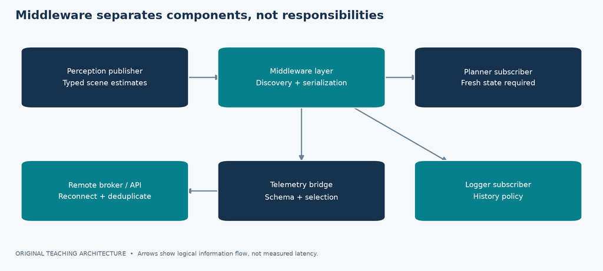

*Figure: Middleware separates components, not responsibilities. Original conceptual diagram; see the surrounding text for assumptions.*

## DDS and ROS 2

OMG DDS defines a data-centric publish–subscribe model with participants, topics, readers, writers and quality-of-service policies. The cited edition is DDS 1.4. ROS 2 exposes configurable communication QoS, including reliability, history/depth, durability, deadline, lifespan and liveliness; compatibility between offered and requested policies affects whether endpoints communicate. [S9](https://www.omg.org/spec/DDS/1.4/About-DDS), [S10](https://docs.ros.org/en/humble/Concepts/Intermediate/About-Quality-of-Service-Settings.html)

For the teaching system, separate three questions:

1. Can the endpoints discover and match one another?
2. Can the chosen policy deliver usable data under the workload?
3. Does the application interpret that data correctly and act within its budget?

A positive answer to the first does not prove the second or third. A middleware deadline notification identifies a violated expectation; it does not reserve CPU time or repair an overloaded consumer. A reliability setting concerns delivery behavior; it is not an application-level proof of freshness or physical action.

### QoS design worksheet

| Policy | Question to ask in our design | Example choice to evaluate |
| --- | --- | --- |
| Reliability | Is retransmitting an old sample useful? | Best effort for replaceable high-rate samples |
| History/depth | How much backlog remains meaningful? | Keep a small recent window for latest-state data |
| Durability | Should a late joiner obtain previous state? | Preserve a configuration value for late joiners |
| Deadline | How frequently should updates appear? | Detect loss of an expected periodic stream |
| Lifespan | When is a sample no longer useful? | Expire an observation after its validity horizon |
| Liveliness | How is producer presence monitored? | Detect missing assertions or traffic |

The choices in the third column are illustrative. For example, some sensor streams require recovery of every sample for offline analysis, so best effort would be unsuitable there. Specify the consumer's purpose before choosing a profile.

## MQTT, CoAP and service-oriented integration

MQTT 5.0 is a client–server publish/subscribe transport. Its QoS levels are 0 (at most once), 1 (at least once) and 2 (exactly once at the applicable protocol delivery boundary). It also defines retained messages and session-related behavior. These protocol mechanisms do not make an arbitrary actuator or database side effect exactly once. [S11](https://docs.oasis-open.org/mqtt/mqtt/v5.0/os/mqtt-v5.0-os.html)

CoAP's base specification provides a resource-oriented request/response protocol for constrained environments, including confirmable and non-confirmable messages over UDP. Its message exchanges should not be confused with MQTT's brokered topic model. This refers specifically to RFC 7252; extensions are outside the notebook's implementation scope. [S15](https://www.rfc-editor.org/rfc/rfc7252)

For a service-oriented teaching design, a consumer discovers a named service and invokes an operation with a defined schema, result and timeout. REST-style resource APIs and remote procedure calls are two ways to express interactions. Their suitability depends on request volume, streaming needs, language support, failure handling and tooling. No middleware acronym removes the need to specify those requirements.

### Comparison by role

| Candidate | Basic role | Candidate use in our case | Important question |
| --- | --- | --- | --- |
| DDS-based integration | Typed data distribution with QoS | Local multi-component sensor processing | Do policies and discovery behavior match? |
| ROS 2 framework | Robotics application integration | Perception and planning components | Which middleware implementation and settings? |
| MQTT | Brokered topic delivery | Fleet telemetry and status | What happens during broker/client reconnection? |
| CoAP base protocol | Constrained resource access | Small device status/resource operations | What are retry and resource semantics? |
| Request–reply API | Explicit service operation | Historical query or configuration request | Is retrying the operation safe? |

This table compares roles rather than ranking all technologies on a single latency scale. Real performance needs measurement under the same workload and transport conditions.

## Serialization, schema evolution and semantics

Our message schema includes a numeric value, unit, timestamp, frame and version. A receiver that decodes bytes successfully may still misunderstand units. A migration from an optional field to a mandatory field requires a compatibility rule. A proposed rule is to add optional fields with explicit defaults only when the default has valid meaning; otherwise reject unsupported versions.

Binary serialization can reduce representation overhead in some workloads, while text representation can simplify inspection. The relevant experiment measures encoded size, CPU time and evolution behavior for the actual schema. A small payload is not an automatic guarantee of a small total packet once transport and security overhead are included.

### Exactly-once effect: an original transaction pattern

```
Receive operation with stable ID
             |
Begin transaction
             |
ID already committed? -- yes --> return saved result
             | no
Validate preconditions --> apply state change --> store ID + result
             |
Commit atomically --> acknowledge
```

The atomic boundary is essential. If the side effect and ID record commit separately, a crash between them reopens the duplication window. For a physical actuator outside the database transaction, a further device protocol, state feedback or reconciled command state is needed; the database pattern alone is insufficient. The lab deliberately models an in-memory, single-process case and states that limitation.

### Case study — perception, planner and telemetry bridge

**Hypothetical design:** a perception component publishes scene estimates; a planner consumes the most recent valid estimate; a logger wants a durable history; a bridge uploads selected statistics. The planner and logger have different data-loss and freshness needs. Using one oversized reliable queue for everyone may deliver stale estimates to the planner while increasing memory use.

**Experiment:** pause the planner for half a second. Compare an unbounded FIFO with a bounded latest-state policy. Record the age of the first sample used after recovery, not only whether all samples eventually arrived. Then pause the logger and verify that any loss is explicitly reported according to its separate policy.

**Checkpoint:** explain QoS compatibility, delivery versus side effects, schema versus serialization, retained state versus history, and why retrying a timed-out request can execute an operation twice.

# Chapter 7 — Data Synchronization

## Four different synchronization problems

**Clock synchronization** relates physical timestamps at different nodes. **Temporal alignment** selects observations referring to comparable physical times. **Replica synchronization** transfers state changes between stores. **Process coordination** establishes an execution relation, such as waiting for all workers at a barrier. Solving one does not solve all four.

For example, two servers can have well-aligned clocks but different data because a replication link is disconnected. Two replicas can contain identical data but have incorrect wall clocks. A camera and a position sensor can both deliver messages reliably yet represent different instants. Start by naming the synchronization problem.

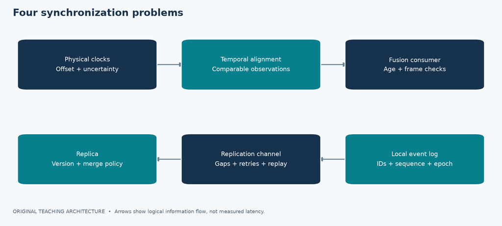

*Figure: Four synchronization problems. Original conceptual diagram; see the surrounding text for assumptions.*

## Physical clocks: offset, rate error and uncertainty

Use the teaching model $C_i(t)=a_it+b_i$. Here $b_i$ is a clock offset and $a_i-1$ is a rate error relative to reference time. Over a short interval this affine model is convenient; real oscillators and corrections can vary. A drift of 20 parts per million means a rate error magnitude of $20\times10^{-6}$ seconds per second under the assumed bound.

If two clocks each drift by at most $\rho$ in opposite directions, their relative uncertainty can grow by $2\rho T$ over an unsynchronized duration $T$. With initial pairwise uncertainty $\epsilon_0$, a conservative model is

$$\epsilon_{pair}(T)\le\epsilon_0+2\rho T.$$

This bound follows directly by adding each clock's possible deviation. It is valid only while the assumed rate bound holds. Sudden clock steps or reference faults require additional handling.

### Four-timestamp exchange

RFC 5905 defines NTPv4 and its time-transfer calculations. Let $t_1$ be client send time, $t_2$ server receipt, $t_3$ server send and $t_4$ client receipt. The offset estimate (server relative to client) and round-trip network delay estimate are:

$$\theta=\frac{(t_2-t_1)+(t_3-t_4)}2,\qquad\delta=(t_4-t_1)-(t_3-t_2).$$

The offset estimate is affected by path asymmetry; exchanging timestamps does not make one-way delay known. The numerical uses symmetric path delay as an explicit assumption. [S13](https://www.rfc-editor.org/rfc/rfc5905)

Precision Time Protocol is another synchronization family, but this notebook does not claim a particular PTP profile, hardware timestamping accuracy or implementation guarantee. Such accuracy depends on the selected profile and deployment. The worked material instead focuses on uncertainty accounting that applies regardless of the chosen clock source.

## Temporal alignment and data age

For observations with timestamps $t_a,t_b$ and uncertainty bounds $\epsilon_a,\epsilon_b$, an upper bound on their physical separation is $|t_a-t_b|+\epsilon_a+\epsilon_b$. A proposed fusion policy accepts them only when that upper bound is below its tolerance. This conservative rule is an original teaching policy; probabilistic fusion may use richer uncertainty models.

If the latest usable observation was generated at $u(t)$, define age $\Delta(t)=t-u(t)$ using a common time reference. Age increases between usable updates and drops when a newer observation arrives. An old reordered packet should not make $u(t)$ move backward. A high delivery ratio does not imply low age if messages wait a long time in a queue.

For a simple kinematic bound with speed magnitude bounded by $v_{max}$, positional movement over an age interval is at most $v_{max}\Delta$. A model with known initial speed and bounded acceleration instead uses $v_0\Delta+\tfrac12 a_{max}\Delta^2$ for a conservative forward-displacement calculation under its stated assumptions. This quantifies why milliseconds can matter without inventing a universal application deadline.

## Logical clocks and causal ordering

Lamport's happened-before relation orders events in one process, message send before receipt, and their transitive consequences. A scalar logical clock increments for local events; a receiver sets its clock to one greater than the maximum of its local value and the received value. If $a\rightarrow b$, then $L(a)<L(b)$, but the reverse implication is not generally valid. Logical time is not elapsed physical time. [S14](https://lamport.azurewebsites.net/pubs/time-clocks.pdf)

Our two-process trace is:

```
Process A                        Process B
local event: L=1
send message: L=2 -------------> receive: max(0,2)+1 = 3
                                 local event: L=4
receive: max(2,5)+1 = 6 <------- send reply: L=5
```

Sorting by `(logical_clock, process_id)` can define a deterministic total order for this trace. It does not prove that two independently generated events causally influenced one another.

### Vector-clock teaching model

Give each of $n$ fixed participants one vector component. A process increments its own component for an event; a receiver takes componentwise maxima and increments its own component. Under this model, $V_a<V_b$ means every component of $V_a$ is at most the corresponding component of $V_b$, with at least one strict inequality. Incomparable vectors identify concurrent histories in the model. Vector metadata grows with the participant set. Replicated data-type research uses causal metadata and distinguishes concurrent updates from ordered ones. [S17](https://arxiv.org/abs/1805.06358)

The numerical and lab construct the update rules directly, so their conclusions can be checked without assuming real-time clock agreement. A changing membership system needs an identity and metadata-management policy beyond this fixed-vector demonstration.

## Synchronizing replicas

Our teaching replication pipeline is **local durable append → send changes → validate → apply idempotently → acknowledge progress → retain until safe to compact**. It should distinguish the highest sequence number seen from the highest contiguous sequence applied. Receiving events 1, 2 and 4 does not establish that event 3 has been processed.

**Snapshot synchronization** transfers a state image. **Incremental synchronization** transfers changes since a known point. A snapshot should include the log position it represents; otherwise replay can omit or double-apply updates around the capture boundary. **Anti-entropy** is a periodic reconciliation process that discovers and repairs differences. A digest mismatch indicates difference, not automatically which side is correct.

### Reconnection algorithm for the teaching fleet

1. Exchange producer identity, boot epoch and contiguous acknowledged position.
2. Request missing events or a checkpoint when the retained log no longer covers the gap.
3. Verify schema, provenance and event identity.
4. Apply historical observations to their historical intervals; do not relabel them as current.
5. Resolve concurrent mutable updates under a declared policy.
6. Advance durable acknowledgment only after the required commit boundary.

### Case study — tunnel exit and delayed uploads

**Hypothetical conditions:** a vehicle records data during a 90-second disconnection. On reconnection it uploads a backlog while producing new observations. **Design:** durable history enters a replay channel; current-state observations enter an expiry-aware channel. The receiver preserves observation timestamps and displays backlog status separately from current coverage.

**Failure to demonstrate:** if upload capacity equals current production, no bandwidth remains to drain the backlog. “The link is back” does not mean replicas will catch up. The backlog numerical calculates net drain capacity. **Another failure:** after a reboot, sequence counters restart; without an epoch, the receiver may suppress valid events as duplicates.

**Checkpoint:** derive pairwise drift, calculate NTP offset with sign interpretation, distinguish concurrency from equal clock values, explain the snapshot/log boundary, and show how reordered delivery affects data age.

# Chapter 8 — Data Consistency in Distributed Autonomous Systems

## What consistency specifies

A consistency model specifies which observations of shared state are permitted. It is a contract visible to clients, not simply the statement that replicas eventually contain matching bytes. The correct contract depends on the object and operation. Our reference system contains telemetry, configuration, hazard events and exclusive reservations; applying the same rule to all four ignores their different consequences.

Distinguish **replica consistency**, **transaction isolation**, **application validity** and **temporal freshness**. Two replicas may agree on a stale value. A transaction can be isolated yet apply an incorrect business rule. A fresh measurement can be physically wrong. These are separate dimensions to test.

## Consistency models through original histories

### Linearizability

A linearizable object behaves as if operations take effect atomically in one order that respects completed-before-started real-time relationships. Consider a register initially zero: client A completes `write(1)`; afterward client B starts `read()`. Returning zero would violate linearizability for that register. Concurrent operations have more freedom because their calls overlap. This is the atomic-consistency property used in the CAP result. [S16](https://pld.cs.luc.edu/database/gilbert_lynch_brewer_proof.pdf)

For our reservation service, the useful operation is not `read free` followed later by `write owner`. Those two separately linearizable operations can race. Instead, use an atomic conditional acquisition such as `acquire_if_free(slot, owner, epoch)`. State the operation boundary before claiming that consistency prevents double allocation.

### Sequential consistency

The teaching contract requires one order consistent with each process's program order, but not necessarily with real-time precedence across different processes. A delayed cross-client observation can therefore be allowed even where a linearizable register would reject it. This comparison is conceptual; the notebook does not implement a complete sequentially consistent store. Lamport's logical-ordering work supplies the foundational distinction between causal/process order and physical time. [S14](https://lamport.azurewebsites.net/pubs/time-clocks.pdf)

### Causal consistency

If an operation depends on an earlier operation, observers should not see the dependent effect without its cause under a causal contract. Our example publishes a map version, then a route computed using that version. A consumer should not apply the route while lacking the required map. Concurrent independent edits need not receive the same total order. Causal dependencies and replicated update semantics are treated in the replicated-data-type literature. [S17](https://arxiv.org/abs/1805.06358)

### Eventual consistency and session guarantees

An eventual-convergence contract allows temporary replica differences, with convergence under the stated conditions for propagation and update quiescence. It does not by itself provide a fixed staleness bound. A design can add **read-your-writes** for one client's updates or **monotonic reads** so that a client does not move backward in its observed history. These are useful explicit requirements in our fleet dashboard; do not assume them from the word “eventual.”

Our proposed bounded-staleness contract additionally states a maximum allowed lag and what happens when that bound cannot be met. Returning an unavailable response or a visibly stale result are different APIs. Without an enforcement rule, the claimed bound is only an aspiration.

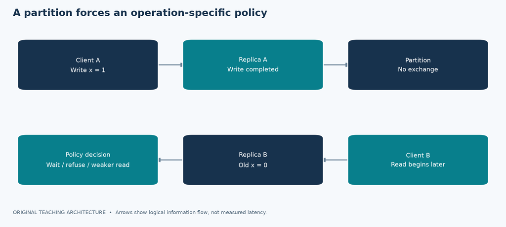

*Figure: A partition forces an operation-specific policy. Original conceptual diagram; see the surrounding text for assumptions.*

## CAP: a partition argument rather than a slogan

Gilbert and Lynch formalize the incompatibility of atomic consistency and availability in an asynchronous system that permits partitions. The availability definition requires requests at non-failing nodes to complete; it is not a percentage uptime SLA. [S16](https://pld.cs.luc.edu/database/gilbert_lynch_brewer_proof.pdf)

**Original two-replica construction:** A and B start with `x=0`. A partition prevents exchange. A accepts and completes `write(x=1)`. A later read at B cannot learn whether that write occurred. If B must answer from its old state, it can violate the atomic register contract; if it waits indefinitely for communication, it gives up the specified availability. An error response that refuses the requested operation is not a magical way to satisfy both guarantees.

The design implication is to specify behavior **per operation during a partition**. Our telemetry collector may accept independent append-only records. Our exclusive reservation service may refuse a new grant on a side that cannot establish authority. Labeling an entire application “AP” or “CP” without identifying operations hides this distinction.

## Quorums and their limits

With a fixed set of $N$ replicas, $W_q$ acknowledgments per completed write and $R_q$ replicas per read, $R_q+W_q>N$ ensures that every read set intersects every write set. To see why, two disjoint sets would require $R_q+W_q$ distinct members, exceeding $N$. Similarly, $2W_q>N$ forces write-set intersection.

These are set-intersection results. They do **not** by themselves establish linearizability. A protocol must also define version order, concurrent writes, incomplete writes, read repair, failures, membership changes and what a reader returns. The lab enumerates set intersections; it deliberately does not call that enumeration a database correctness proof.

For $N=5$, $R_q=3,W_q=3$ guarantees overlap and permits completion with any three reachable replicas under the toy assumptions. After a 3–2 partition, only the three-node side can form a majority. Two nodes accepting conflicting writes independently would violate the intended authority rule.

## Consensus and replicated state machines

Raft organizes replicated state-machine operation around leader election, log replication and safety constraints. For crash-fault operation, a majority is needed for progress in the usual fixed-membership setting; $2f+1$ nodes permit a majority after up to $f$ failures. A correct implementation also needs the paper's log, term, commit and election rules, not just a vote counter. [S12](https://raft.github.io/raft.pdf)

Our teaching sequence is **client command → leader log → follower replication → quorum acknowledgment under the protocol → commit → deterministic apply → reply**. Deterministic apply means replicas given the same committed command sequence produce the same logical state. External side effects and nondeterministic inputs need explicit treatment. The notebook's majority arithmetic does not implement Raft.

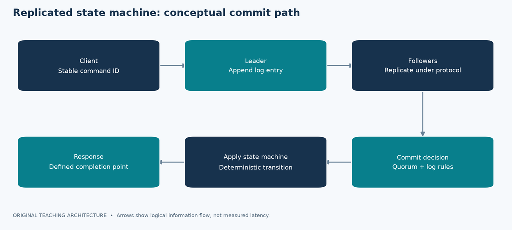

*Figure: Replicated state machine: conceptual commit path. Original conceptual diagram; see the surrounding text for assumptions.*

Consensus does not promise bounded completion under arbitrary delay. A minority may remain alive but unable to commit. Failure detection based on timeouts can suspect a slow node; a timeout is not proof of death. Separate **safety** (“no conflicting committed decisions under the model”) from **liveness** (“eventual progress under the required conditions”).

## CRDTs and conflict resolution

CRDTs provide data types whose permitted concurrent updates converge through mathematically defined rules. State-based merge functions commonly use associative, commutative and idempotent joins with appropriate monotonic state evolution; operation-based designs have their own delivery assumptions. This is not permission to merge arbitrary application state by any convenient rule. [S17](https://arxiv.org/abs/1805.06358), [S18](https://www.microsoft.com/en-us/research/publication/replicated-data-types-specification-verification-optimality/)

### Original grow-only counter example

Give each fixed replica a private nonnegative counter component. A replica increments only its component. The reported count is the sum. Merge vectors by componentwise maximum. With A state `(3,0)` and B state `(0,5)`, merge gives `(3,5)` and count 8. Merging the same state twice changes nothing because `max(x,x)=x`. Thus duplicated state transfer does not double-count these increments.

This counts increments, not necessarily distinct physical incidents. If A and B both independently count the same physical event, the result includes both increments. Deduplicating physical identity is a separate data-model problem. A grow-only counter also cannot represent arbitrary decrement or exclusive ownership without another construction.

### Last-writer-wins and lost intent

Our teaching last-writer-wins register selects the highest `(timestamp, replica_id)` tuple. It is deterministic for the supplied metadata, but clock skew may make an earlier physical action appear later. Even perfect clocks do not preserve both users' incompatible intentions. A deterministic winner is not the same as an application-correct resolution. For an exclusive physical resource, silently choosing a winner after both sides acted is too late.

## Leases, epochs and fencing

A lease grants time-bounded authority under explicit time assumptions. An epoch or fencing token orders ownership generations. In our design, every write to an actuator-facing resource carries a token, and the receiver rejects a token lower than the greatest accepted token. Without enforcement at the resource boundary, a token is just metadata.

Our example old leader pauses, its lease expires, and a new leader receives token 12. The old leader resumes with token 11. The resource rejects 11 after accepting 12. This illustrates stale-owner rejection; it is not a full distributed lock implementation. Token issuance itself needs coordinated authority, and physical actions may need additional interlocks.

### Case study — two robots and one charging bay

**Invariant:** at most one valid reservation grants entry to a bay for an overlapping interval. **Proposed service:** atomic conditional acquisition in a coordinated state machine; commands include reservation identity and ownership epoch; the local bay interface checks permission before entry. Telemetry is collected separately with delayed reconciliation permitted.

**Partition behavior:** a robot unable to obtain a valid grant waits or follows a defined alternative. It does not infer permission from an old cached “free” value. **Failure test:** deliver a stale command after failover, duplicate an acquisition request and lose a reply after commit. Verify token rejection, stable operation identity and read-back of the original outcome.

**Trade-off:** refusing a grant can reduce utilization during an outage. Accepting conflicting grants may violate the invariant. This is a concrete availability cost of the selected requirement, not a reason to pretend the conflict does not exist.

## Object-by-object selection matrix

| Object | Proposed contract | Partition behavior | What the contract does not prove |
| --- | --- | --- | --- |
| Immutable diagnostic event | Append with deduplication and eventual upload | Buffer within a declared limit | That the diagnosis is correct |
| Latest sensor estimate | Freshness bound plus source/version | Expire or degrade when too old | Agreement with physical truth |
| Map/configuration bundle | Version-coherent activation | Retain compatible active version | That the map is currently accurate |
| Exclusive reservation | Atomic conditional update and enforced authority | Refuse grants without authority | Physical collision avoidance by itself |
| Distributed activity counter | Suitable CRDT semantics | Accept permitted local increments | Unique counting of real-world events |

**Checkpoint:** critique “pick any two,” “a majority proves linearizability,” “eventual means within one second,” and “CRDTs solve every conflict.” A strong answer replaces each slogan with its assumptions, counterexample and operational consequence.

# Worked numerical problems — all eight topics

Every input in this section is **hypothetical teaching data**. The results follow from the stated equations and assumptions, not measurements of a deployment. Each problem includes a definition, model, units, working and interpretation. The verification lab recomputes the main answers with assertions.

## VANETs — link contact duration

**Question:** Two vehicles on a straight line move apart. Their current separation is 100 m, communication is assumed possible up to 300 m, and relative separation speed is 20 m/s. How long remains before the range threshold is crossed?

**Definition:** remaining contact time is the time until the assumed connectivity condition ceases to hold. **Block diagram:**

```
Vehicle A <--- separation d(t)=100+20t ---> Vehicle B
                  threshold: 300 m
```

**Formula and assumptions:** constant relative motion away from each other, sharp symmetric range boundary, no obstruction or fading; $T=(R-d_0)/v_{rel}$.

**Working:** available separation margin $=300-100=200$ m. Time $=200/20=10$ s. **Answer:** 10 s remaining, with connectivity at the exact boundary defined by the model. **Interpretation:** a 12 s transfer cannot finish within this contact without another path. This is remaining contact, not the full duration of an encounter. If vehicles approach, or travel along different trajectories, solve the appropriate distance equation instead.

## VANETs — offered beacon payload load

**Question:** 120 vehicles each emit ten 300-byte messages per second. Find aggregate payload rate and its fraction of a hypothetical 6 Mbit/s channel capacity.

**Definition:** offered payload load counts generated application bits per second before lower-layer overhead. **Block diagram:**

```
120 producers × 10 messages/s × 300 bytes --> shared channel
```

**Formula:** $G=n f_b L\times8$, with bytes converted to bits. **Working:** message count $=120\times10=1,200$/s; bytes $=1,200\times300=360,000$/s; bits $=2,880,000$/s. Fraction $=2.88/6=0.48$.

**Answer:** 2.88 Mbit/s, or 48% of the stated bit rate as a **payload-only ratio**. **Interpretation:** this is not measured channel busy ratio or delivered throughput. Headers, signatures, contention, coding and retransmissions can change airtime and useful capacity. The 6 Mbit/s value is a problem input, not a claim about a specific deployment.

## VANETs — multihop one-attempt delivery

**Question:** A fixed three-hop path has independent per-hop delivery probabilities 0.95, 0.90 and 0.98. Find probability of delivery in one attempt at each hop.

**Definition:** end-to-end success requires every required hop to succeed. **Block diagram:**

```
Source --0.95--> Relay A --0.90--> Relay B --0.98--> Destination
```

**Formula:** $P=\prod_i p_i$ under independence. **Working:** $0.95\times0.90=0.855$; $0.855\times0.98=0.8379$. **Answer:** 83.79%. **Interpretation:** individual links above 90% do not imply an end-to-end result above 90%. Correlated failures or route changes require a different model. No retransmission is included.

## IoV — fleet ingress

**Question:** 800 vehicles send one 250-byte telemetry record every 0.5 s. Compute raw payload ingress in records/s, bytes/s and Mbit/s.

**Definition:** aggregate ingress is the sum of producer rates for this uniform workload. **Block diagram:**

```
800 vehicle streams --> ingestion gateway --> event log
```

**Formula:** $r=1/T$ records/s per vehicle, $G=nrb\times8$. **Working:** $1/0.5=2$ records/s each; $800\times2=1,600$ records/s; $1,600\times250=400,000$ bytes/s; $400,000\times8=3,200,000$ bit/s.

**Answer:** 1,600 records/s, 0.4 MB/s, 3.2 Mbit/s. **Interpretation:** this is continuous average generation under the uniform model. Reconnection bursts can create a higher arrival rate at the backend even if generation is unchanged.

## IoV — outage buffer

**Question:** One vehicle generates 50 records/s, each 400 bytes, during a 90 s outage. Find minimum raw payload buffer and a proposed 25% margin allocation.

**Definition:** outage buffering retains generated records while transmission is unavailable. **Block diagram:**

```
Producer --> local outbox --X disconnected uplink X--> server
```

**Formula:** $B=rbt$. **Working:** generation $=50\times400=20,000$ bytes/s; backlog $=20,000\times90=1,800,000$ bytes. Margin allocation $=1.25\times1,800,000=2,250,000$ bytes.

**Answer:** 1.8 MB raw payload; 2.25 MB under the chosen 25% allocation margin. **Interpretation:** the margin is a teaching choice, not a proven provision for indexes, filesystem overhead or a longer outage. Use measured overhead and an explicit outage requirement for real dimensioning.

## IoV — budget allocation across a service path

**Question:** An illustrative service has a 100 ms deadline. Sensing, encoding, uplink, compute, downlink and consumer handling take 8, 4, 15, 20, 12 and 6 ms respectively. How much remains for queueing and additional overhead?

**Definition:** timing slack is deadline minus the sum of accounted sequential costs. **Block diagram:**

```
Sense 8 --> Encode 4 --> Up 15 --> Compute 20 --> Down 12 --> Use 6
```

**Formula:** $S=D-\sum_i T_i$. **Working:** sum $=8+4+15+20+12+6=65$ ms; slack $=100-65=35$ ms.

**Answer:** 35 ms. **Interpretation:** if the component numbers are means, the result is a mean-based budget, not a hard guarantee. If all are justified bounds for the same sequential path, the remaining 35 ms is a bound budget for the omitted work.

## Edge — local versus remote execution

**Question:** A task requires $2\times10^9$ cycles. Local processing is $10^9$ cycles/s; edge processing is $10^{10}$ cycles/s. Input is 8 Mbit and output 0.8 Mbit. Uplink is 20 Mbit/s, downlink 40 Mbit/s, fixed overhead 0.03 s and edge queueing 0.05 s. Compare execution times.

**Definition:** offloading time includes sequential data transfer, waiting and remote execution. **Block diagram:**

```
Local: task --> local CPU
Edge : upload --> overhead/queue --> edge CPU --> download
```

**Formula:** $T_l=C/f_l$; $T_e=B_u/R_u+T_o+T_q+C/f_e+B_d/R_d$.

**Working:** local $=2\times10^9/10^9=2$ s. Upload $=8/20=0.4$ s. Edge compute $=2/10=0.2$ s. Download $=0.8/40=0.02$ s. Total $=0.4+0.03+0.05+0.2+0.02=0.70$ s.

**Answer:** local 2 s; remote 0.70 s; saving 1.30 s or 65% of local time. **Interpretation:** a 0.5 s deadline is still missed by both choices. “Faster” is not the same as “feasible.”

## Edge — bandwidth threshold

**Question:** Using the previous task, find the uplink rate that makes remote and local execution equal in this model.

**Definition:** the break-even rate is the rate at which both candidate path times match. **Block diagram:**

```
Input 8 Mbit / variable uplink --> fixed remote remainder 0.30 s
```

**Formula:** $R_u=B_u/(T_l-T_r)$. **Working:** remote remainder $T_r=0.03+0.05+0.2+0.02=0.30$ s. Upload allowance $=2-0.30=1.70$ s. Rate $=8/1.70=4.705882$ Mbit/s.

**Answer:** approximately 4.706 Mbit/s gives equality; higher rates make remote execution faster with all other assumptions unchanged. **Interpretation:** equality is not a margin for fluctuating bandwidth. Queue growth can shift this threshold.

## Edge — queueing near saturation

**Question:** An M/M/1 server completes a mean 100 jobs/s. Compare mean system response time at arrival rates 60 and 90 jobs/s.

**Definition:** system response includes waiting plus service. **Block diagram:**

```
Poisson arrivals λ --> unbounded FIFO --> exponential server μ=100/s
```

**Formula:** $W=1/(\mu-\lambda)$ with $\lambda<\mu$. **Working:** at 60/s, $W=1/40=0.025$ s = 25 ms. At 90/s, $W=1/10=0.1$ s = 100 ms. Mean service is $1/100=10$ ms, so waiting is 15 and 90 ms respectively.

**Answer:** 25 ms versus 100 ms mean response. **Interpretation:** a 50% arrival-rate increase quadruples mean response in this model. These are not worst-case delays; the assumed distributions have unbounded tails.

## Fog — aggregation and backhaul reduction

**Question:** Twenty roadside nodes each emit 2 Mbit/s raw payload. A regional processor forwards summaries equal to 15% of the raw aggregate. Find outgoing rate and reduction.

**Definition:** reduction compares output payload to input payload under a stated summary policy. **Block diagram:**

```
20 × 2 Mbit/s --> regional aggregation --> 15% summary stream
```

**Formula:** $G_{raw}=nr$; $G_{out}=\alpha G_{raw}$; reduction $=(1-\alpha)100\%$. **Working:** raw $=20\times2=40$ Mbit/s; output $=0.15\times40=6$ Mbit/s; saving $=34$ Mbit/s.

**Answer:** 6 Mbit/s outgoing and 85% payload reduction. **Interpretation:** the assumed ratio does not establish that the summary preserves every downstream requirement. The computation and local input traffic still exist.

## Fog — parallel branches and a join

**Question:** A pipeline first spends 5 ms on ingestion, then executes two independent branches taking 12 and 20 ms. A join takes 4 ms, and output transport takes 6 ms. Find total delay if branches start together on separate resources.

**Definition:** a join waits for all required branches; its start is set by the slowest predecessor. **Block diagram:**

```
                    +--> branch A: 12 --+
Ingest: 5 ----------|                  |--> Join: 4 --> Output: 6
                    +--> branch B: 20 --+
```

**Formula:** $T=5+\max(12,20)+4+6$. **Working:** parallel stage $=20$ ms; total $=5+20+4+6=35$ ms.

**Answer:** 35 ms. **Interpretation:** adding both branches would give 47 ms and overcount the parallel interval. If the branches share a serialized processor, the original assumption fails and a different schedule must be analyzed.

## Fog — checkpoint transfer

**Question:** A state checkpoint contains 60 MB. Effective transfer rate is 120 Mbit/s, with 0.2 s setup. Assume no new state changes. Find completion time.

**Definition:** checkpoint transfer moves a finite state image under a stated consistency boundary. **Block diagram:**

```
Source snapshot 60 MB --> 120 Mbit/s link --> destination restore input
```

**Formula:** $T=8S/R+T_{setup}$ when $S$ is expressed in decimal MB and $R$ in Mbit/s. **Working:** size $=60\times8=480$ Mbit; transfer $=480/120=4$ s; total $=4+0.2=4.2$ s.

**Answer:** 4.2 s to deliver the image including setup. **Interpretation:** restore time, replay and ownership transfer are excluded. Do not label this full service downtime unless the migration protocol establishes that equivalence.

## Cloud — daily storage

**Question:** 1,000 vehicles send two 500-byte records each second for a day. Compute raw daily payload and a hypothetical three-copy storage total, excluding indexes and compression.

**Definition:** storage volume is production rate integrated over retention time. **Block diagram:**

```
Vehicle streams --> 86,400 s of records --> storage --> 3 copies
```

**Formula:** $S=nrbt$; copied payload $=kS$. **Working:** rate $=1,000\times2\times500=1,000,000$ bytes/s. Daily $=1,000,000\times86,400=86,400,000,000$ bytes = 86.4 GB. Three copies $=259.2$ GB.

**Answer:** 86.4 GB raw per day; 259.2 GB for the assumed three payload copies. **Interpretation:** indexes, metadata, backup retention and different replication implementations can change billable storage. No monetary cost is inferred.

## Cloud — allowed downtime arithmetic

**Question:** Convert a 99.9% availability target into total unavailable minutes during a specified 30-day observation interval.

**Definition:** time-based availability is available time divided by the defined eligible observation time. **Block diagram:**

```
30-day eligible interval --> available fraction 0.999 + unavailable 0.001
```

**Formula:** $U=(1-A)T$. **Working:** total $=30\times24\times60=43,200$ minutes; unavailable fraction $=0.001$; $U=43.2$ minutes.

**Answer:** 43.2 minutes. **Interpretation:** this is arithmetic for a chosen metric, not a provider SLA interpretation. Exclusions, request-based definitions and whether partial failures count must be specified separately.

## Cloud — sequential dependency availability

**Question:** An application requires three independent services with availabilities 0.999, 0.995 and 0.999. Find the probability all three are available at a randomly sampled instant under this model.

**Definition:** a series system works only if every required component works. **Block diagram:**

```
API 0.999 --> database 0.995 --> required identity service 0.999
```

**Formula:** $A=\prod_i A_i$. **Working:** $0.999^2=0.998001$; $0.998001\times0.995=0.993010995$.

**Answer:** approximately 99.3011%. **Interpretation:** common-cause failures invalidate independence. Also verify whether the identity service really is required for every request; cached valid credentials would produce a different dependency graph.

## Middleware — fan-out load

**Question:** A publisher generates 200 messages/s of 1,000 bytes. A broker sends a full copy to each of six subscribers. Find publisher payload ingress and broker payload egress, ignoring overhead.

**Definition:** fan-out multiplies transmitted copies when each subscriber needs a separate copy. **Block diagram:**

```
Publisher --> broker --> S1, S2, S3, S4, S5, S6
```

**Formula:** $G_{in}=rL\times8$ and $G_{out}=kG_{in}$. **Working:** ingress $=200\times1,000\times8=1.6$ Mbit/s; egress $=6\times1.6=9.6$ Mbit/s.

**Answer:** 1.6 Mbit/s publisher payload ingress, 9.6 Mbit/s broker payload egress. **Interpretation:** multicast or other transport strategies could change the copy accounting. This problem explicitly assumes separate full copies.

## Middleware — bounded queue drain

**Question:** A consumer can process 80 records/s. A burst leaves 120 queued records, while new arrivals continue at 50/s. Estimate time to drain the queue using a deterministic fluid model.

**Definition:** net drain rate is service minus ongoing input while backlog exists. **Block diagram:**

```
50 records/s --> [120-record backlog] --> consumer 80 records/s
```

**Formula:** $T=B/(\mu-\lambda)$ with positive net capacity. **Working:** net drain $=80-50=30$ records/s; $T=120/30=4$ s.

**Answer:** 4 s in the fluid model. **Interpretation:** $120/80=1.5$ s incorrectly ignores new arrivals. Discrete scheduling and variable service can alter exact completion time. If input rises to 80/s, the backlog does not drain under this model.

## Middleware — duplicate suppression

**Question:** The delivered operation IDs are `a, b, a, c, b, d`. Every unique operation adds 10 to an application counter. Find the naive and deduplicated totals.

**Definition:** idempotent processing prevents repeated delivery of the same operation from repeating its effect within the declared identity scope. **Block diagram:**

```
Delivered IDs --> atomic seen-ID check --> apply unique effect --> state
```

**Formula:** naive $=n\times10$; deduplicated $=|\{IDs\}|\times10$. **Working:** six deliveries produce 60 naively. Unique IDs are four: a, b, c, d. Four effects produce 40.

**Answer:** naive 60; intended deduplicated 40. **Interpretation:** IDs must be stable across retries, and the check and effect must share an appropriate atomic boundary. Regenerating a new ID on each retry defeats this policy.

## Synchronization — NTP-style offset

**Question:** Four timestamps in seconds are $t_1=10.000$, $t_2=10.130$, $t_3=10.150$, $t_4=10.080$. Calculate offset and network round-trip delay. Assume symmetric path delay for interpreting the offset.

**Definition:** offset estimates server clock minus client clock; network delay subtracts server processing from the client-measured round trip. **Block diagram:**

```
Client t1=10.000 ------> Server t2=10.130
Client t4=10.080 <------ Server t3=10.150
```

**Formula:** $\theta=[(t_2-t_1)+(t_3-t_4)]/2$; $\delta=(t_4-t_1)-(t_3-t_2)$. [S13](https://www.rfc-editor.org/rfc/rfc5905)

**Working:** $\theta=(0.130+0.070)/2=0.100$ s. Server processing $=0.020$ s; client elapsed $=0.080$ s; $\delta=0.060$ s.

**Answer:** server clock estimated 100 ms ahead; network RTT 60 ms. **Interpretation:** the server's timestamps can numerically exceed the later client timestamp because these are different clocks. Under symmetry, each path is 30 ms; without symmetry the offset has an asymmetry error.

## Synchronization — maximum resynchronization interval

**Question:** Two clocks each have drift magnitude bounded by 20 ppm. Initial pairwise uncertainty is 0.2 ms; the allowed pairwise uncertainty is 2 ms. Find the longest interval allowed by the simple drift bound.

**Definition:** uncertainty grows as the two clocks may drift in opposite directions. **Block diagram:**

```
Clock A: +20 ppm <-- common synchronization --> Clock B: -20 ppm
```

**Formula:** $\epsilon_0+2\rho T\le\epsilon_{max}$. **Working:** uncertainty budget $=2-0.2=1.8$ ms $=0.0018$ s. Relative drift bound $=40\times10^{-6}$ s/s. $T\le0.0018/(40\times10^{-6})=45$ s.

**Answer:** at most 45 s under the stated rate bound. **Interpretation:** the engineering interval would normally allow room for unmodeled error, but no arbitrary margin is imposed here. Clock jumps violate this simple model.

## Synchronization — data age and motion

**Question:** A usable observation was generated at 12.000 s and is consumed at 12.120 s on a common time reference. Speed magnitude is bounded by 25 m/s. Find age and the associated movement bound.

**Definition:** age measures time since generation; a speed bound limits distance traversed in that interval. **Block diagram:**

```
Observe at 12.000 --> transmission + queue + processing --> use at 12.120
```

**Formula:** $\Delta=t-u$; $d\le v_{max}\Delta$. **Working:** age $=0.120$ s; movement $\le25\times0.120=3$ m.

**Answer:** 120 ms age and at most 3 m movement under the speed bound. **Interpretation:** 3 m is not automatically the actual localization error; prediction may compensate motion, while initial measurement error remains a separate term.

## Consistency — quorum sizing and crash tolerance

**Question:** A fixed five-replica system uses reads from three and writes acknowledged by three. Check read/write and write/write intersection and majority crash tolerance.

**Definition:** intersection requires overlapping replica sets; majority tolerance counts how many failures leave a majority. **Block diagram:**

```
Five replicas: [A] [B] [C] [D] [E]
Read any 3; write any 3; majority = 3
```

**Formula:** $R_q+W_q>N$, $2W_q>N$, and majority size $\lfloor N/2\rfloor+1$. **Working:** $3+3=6>5$; $2\times3=6>5$; majority $=3$; removable nodes $=5-3=2$.

**Answer:** both intersections hold; any two crash failures leave three replicas. **Interpretation:** these are necessary set and availability calculations for the toy arrangement, not a full proof of a storage protocol's linearizability. Losing three nodes prevents majority progress. [S12](https://raft.github.io/raft.pdf)

## Consistency — vector concurrency

**Question:** Compare vectors $A=(2,1,0)$ and $B=(1,2,0)$. Compute their componentwise merge and the vector after participant C receives that merged state and records one event.

**Definition:** componentwise partial order detects whether one represented history includes another. **Block diagram:**

```
A (2,1,0) --+
             +--> max merge (2,2,0) --> C event
B (1,2,0) --+
```

**Formula:** $A\le B$ iff each $A_i\le B_i$; merge $M_i=\max(A_i,B_i)$. **Working:** A's first component exceeds B's, while B's second exceeds A's; neither dominates. Merge $=(2,2,0)$. Increment C's component: $(2,2,1)$.

**Answer:** concurrent vectors; merged $(2,2,0)$; C's event $(2,2,1)$. **Interpretation:** the vector does not state how many seconds apart the events occurred. It records the constructed causal history.

## Consistency — grow-only counter merge

**Question:** Three replicas have counter states $A=(4,0,0)$, $B=(2,3,0)$ and $C=(0,1,5)$. Find the merged counter and the result of merging A again.

**Definition:** a state-based grow-only counter stores one monotonic component per writer and joins by maximum. **Block diagram:**

```
A (4,0,0) --+
B (2,3,0) --+--> componentwise maximum --> sum components
C (0,1,5) --+
```

**Formula:** $M_i=\max(A_i,B_i,C_i)$; value $=\sum_i M_i$. **Working:** maxima $=(4,3,5)$; sum $=4+3+5=12$. Merging A again yields $(\max(4,4),\max(3,0),\max(5,0))=(4,3,5)$.

**Answer:** count 12, unchanged on duplicate merge. **Interpretation:** summing the replica totals would give $4+5+6=15$ and count shared history repeatedly. This construction assumes each writer alone increments its assigned component. [S17](https://arxiv.org/abs/1805.06358)

# Executable laboratories

Eight topic-aligned labs and an arithmetic verification lab follow. All data are synthetic and all outputs are deterministic. These experiments implement the declared toy models, not complete VANET, ROS, cloud or consensus systems. Edit inputs and rerun to test how assumptions change results.

Run the setup cell first, then run labs in order. The saved notebook already contains their outputs.

```python
import math
import itertools
import numpy as np
import matplotlib.pyplot as plt
from IPython.display import display, Markdown
plt.rcParams.update({'figure.figsize': (10, 4.5), 'font.size': 11,
                     'axes.spines.top': False, 'axes.spines.right': False,
                     'axes.grid': True, 'grid.alpha': 0.2})
TEAL, NAVY, GOLD = '#087F8C', '#17324D', '#D99428'
print('Setup complete. Deterministic teaching models; no external services required.')
```

```
Setup complete. Deterministic teaching models; no external services required.
```

## Lab 1 — VANET contact and a time-dependent connectivity graph

**Objective:** see why an initially usable link may not support a long transfer. Two vehicles separate according to $d(t)=100+20t$ metres and a link exists while $d(t)\le300$. The model deliberately excludes fading, lane geometry, interference and protocol overhead.

**Method:** evaluate distance and connectivity on a time grid; compare the boundary with the analytical contact time. **Expected result:** connectivity ends after 10 s. **Explore:** change relative speed to 10 m/s and predict the new result before running. A zero or negative separating speed needs a different case analysis.

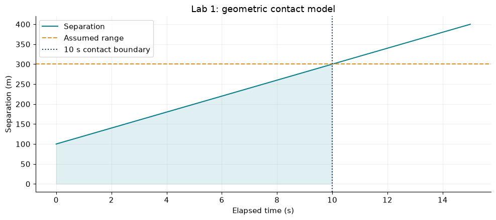

```
Remaining contact: 10.0 s. A 12 s transfer exceeds it by 2.0 s.
This is a geometric demonstration, not measured packet reception.
```

```python
t = np.linspace(0, 15, 301)
distance = 100 + 20*t
connected = distance <= 300
contact_s = (300-100)/20
assert contact_s == 10
fig, ax = plt.subplots()
ax.plot(t, distance, color=TEAL, label='Separation')
ax.axhline(300, color=GOLD, linestyle='--', label='Assumed range')
ax.axvline(contact_s, color=NAVY, linestyle=':', label='10 s contact boundary')
ax.fill_between(t, 0, distance, where=connected, color=TEAL, alpha=.12)
ax.set(xlabel='Elapsed time (s)', ylabel='Separation (m)', title='Lab 1: geometric contact model')
ax.legend(); plt.tight_layout(); plt.show()
print(f'Remaining contact: {contact_s:.1f} s. A 12 s transfer exceeds it by {12-contact_s:.1f} s.')
print('This is a geometric demonstration, not measured packet reception.')
```

## Lab 2 — IoV buffering and reconnect drain

**Objective:** separate the return of connectivity from completion of synchronization. During a 90 s outage, a vehicle generates 20,000 bytes/s. After reconnection the upload service carries 50,000 bytes/s while generation continues.

**Method:** use a deterministic fluid backlog model. Backlog grows at the production rate during outage and shrinks at service minus production afterward. **Expected result:** 1.8 MB peak backlog and 60 s to drain after reconnection. **Limit:** records, disk overhead and bursty service are not modeled. An upload service of 20,000 bytes/s would not drain this backlog.

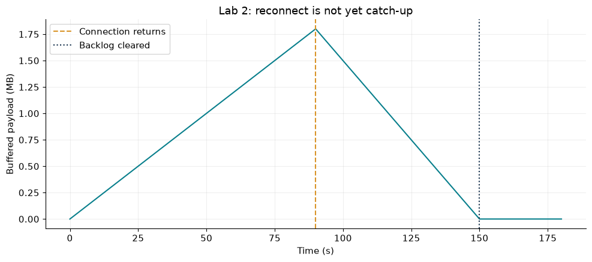

```
Peak backlog = 1.80 MB; post-reconnect drain = 60.0 s.
```

```python
production, service, outage = 20_000, 50_000, 90
peak = production*outage
drain = peak/(service-production)
t = np.arange(0, 181, dtype=float)
backlog = np.where(t <= outage, production*t,
                   np.maximum(0, peak-(service-production)*(t-outage)))
assert peak == 1_800_000 and drain == 60
fig, ax = plt.subplots()
ax.plot(t, backlog/1e6, color=TEAL)
ax.axvline(outage, color=GOLD, linestyle='--', label='Connection returns')
ax.axvline(outage+drain, color=NAVY, linestyle=':', label='Backlog cleared')
ax.set(xlabel='Time (s)', ylabel='Buffered payload (MB)', title='Lab 2: reconnect is not yet catch-up')
ax.legend(); plt.tight_layout(); plt.show()
print(f'Peak backlog = {peak/1e6:.2f} MB; post-reconnect drain = {drain:.1f} s.')
```

## Lab 3 — Edge offloading sensitivity

**Objective:** find when faster remote compute compensates for communication. Use the worked example with 2 s local time, 8 Mbit input and 0.30 s remote non-upload cost.

**Method:** sweep uplink capacity from 1 to 40 Mbit/s. **Expected result:** break-even near 4.706 Mbit/s. A separate queueing plot shows the M/M/1 mean response at service rate 100 jobs/s. **Interpretation:** bandwidth and queueing are independent model inputs; this experiment does not claim that they are independent in a real deployment.

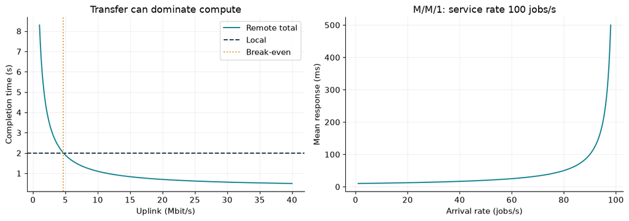

```
Break-even uplink: 4.705882 Mbit/s; at 20 Mbit/s: 0.70 s.
Queueing curve is a mean model, not a worst-case timing bound.
```

```python
rates = np.linspace(1, 40, 300)
remote = 8/rates + .30
threshold = 8/(2-.30)
arrivals = np.linspace(1, 98, 300)
mean_response_ms = 1000/(100-arrivals)
fig, axs = plt.subplots(1,2,figsize=(12,4.3))
axs[0].plot(rates, remote, color=TEAL, label='Remote total')
axs[0].axhline(2, color=NAVY, linestyle='--', label='Local')
axs[0].axvline(threshold, color=GOLD, linestyle=':', label='Break-even')
axs[0].set(xlabel='Uplink (Mbit/s)', ylabel='Completion time (s)', title='Transfer can dominate compute')
axs[0].legend()
axs[1].plot(arrivals, mean_response_ms, color=TEAL)
axs[1].set(xlabel='Arrival rate (jobs/s)', ylabel='Mean response (ms)', title='M/M/1: service rate 100 jobs/s')
plt.tight_layout(); plt.show()
assert math.isclose(8/20+.30, .70)
print(f'Break-even uplink: {threshold:.6f} Mbit/s; at 20 Mbit/s: {8/20+.30:.2f} s.')
print('Queueing curve is a mean model, not a worst-case timing bound.')
```

## Lab 4 — Fog aggregation with missing-source semantics

**Objective:** show why missing cannot be silently converted to zero. Three intersections produce six interval counts. One source is missing in two intervals. Counts are assumed to cover non-overlapping zones so summation is meaningful.

**Method:** compute the observed sum and source coverage. Publish a complete total only when all three sources are present. **Expected result:** intervals 3 and 4 have 2/3 coverage and no complete total. **Explore:** design a labeled estimate instead of suppressing totals, and explain the assumptions needed. This lab does not infer unobserved traffic.

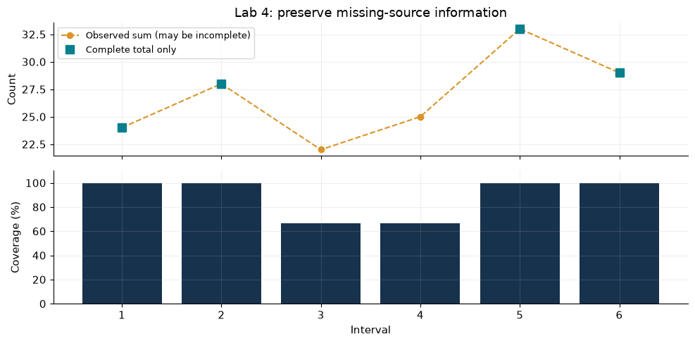

```
Interval 1: observed=24, coverage=100%, complete_total=24.0
Interval 2: observed=28, coverage=100%, complete_total=28.0
Interval 3: observed=22, coverage=67%, complete_total=nan
Interval 4: observed=25, coverage=67%, complete_total=nan
Interval 5: observed=33, coverage=100%, complete_total=33.0
Interval 6: observed=29, coverage=100%, complete_total=29.0
```

```python
counts = np.array([[10,12,14,16,15,13], [8,9,np.nan,np.nan,10,9], [6,7,8,9,8,7]], dtype=float)
observed = np.nansum(counts, axis=0)
coverage = np.isfinite(counts).mean(axis=0)
complete = np.where(coverage == 1, observed, np.nan)
assert np.isnan(complete[2:4]).all()
fig, axs = plt.subplots(2,1,figsize=(10,5),sharex=True)
x = np.arange(1,7)
axs[0].plot(x, observed, 'o--', color=GOLD, label='Observed sum (may be incomplete)')
axs[0].plot(x, complete, 's', color=TEAL, markersize=8, label='Complete total only')
axs[0].set(ylabel='Count', title='Lab 4: preserve missing-source information'); axs[0].legend(fontsize=9)
axs[1].bar(x, coverage*100, color=NAVY)
axs[1].set(xlabel='Interval', ylabel='Coverage (%)', ylim=(0,110))
plt.tight_layout(); plt.show()
for i in range(6):
    print(f'Interval {i+1}: observed={observed[i]:.0f}, coverage={coverage[i]:.0%}, complete_total={complete[i]}')
```

## Lab 5 — Cloud retention and replica accounting

**Objective:** dimension payload storage without hiding the copy multiplier. Assume 1 MB/s raw generation and compare one copy with three copies over 1–30 days.

**Method:** integrate rate over retention. **Expected result:** 86.4 GB/day raw and 259.2 GB/day for three copies. **Limit:** no compression, index, erasure-coding, billing or backup model is implied. **Explore:** add a separately labeled 20% metadata factor and explain why it is an assumption rather than a measured overhead.

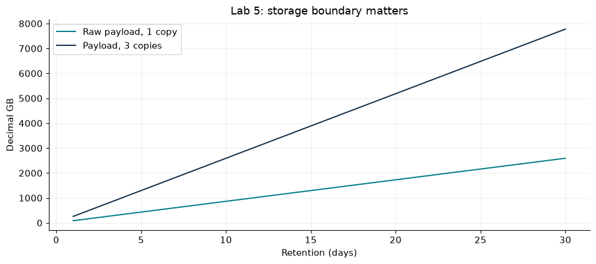

```
Day 1 raw: 86.4 GB; day 30, three copies: 7776.0 GB.
```

```python
days = np.arange(1,31)
raw_gb = 1_000_000*86400*days/1e9
three_copy_gb = 3*raw_gb
assert math.isclose(raw_gb[0],86.4) and math.isclose(three_copy_gb[0],259.2)
fig, ax = plt.subplots()
ax.plot(days, raw_gb, color=TEAL, label='Raw payload, 1 copy')
ax.plot(days, three_copy_gb, color=NAVY, label='Payload, 3 copies')
ax.set(xlabel='Retention (days)', ylabel='Decimal GB', title='Lab 5: storage boundary matters')
ax.legend(); plt.tight_layout(); plt.show()
print(f'Day 1 raw: {raw_gb[0]:.1f} GB; day 30, three copies: {three_copy_gb[-1]:.1f} GB.')
```

## Lab 6 — Middleware retries and idempotent effects

**Objective:** distinguish delivered messages from logical operations. The trace contains repeated IDs after hypothetical lost acknowledgments.

**Method:** compare applying every delivery with applying each unique ID once. **Expected result:** six deliveries, four unique operations, counters 60 and 40. The Python set check and update execute sequentially in this lab. They are **not** a durable concurrent transaction; a production database needs an atomic uniqueness/effect boundary and crash recovery.

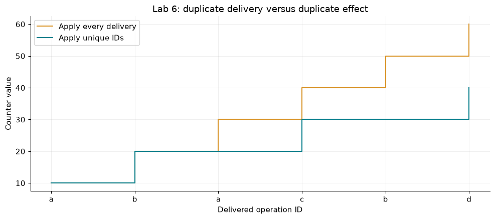

```
Deliveries=6, unique operations=4, naive=60, deduplicated=40.
```

```python
deliveries = ['a','b','a','c','b','d']
seen=set(); naive=0; deduplicated=0; naive_trace=[]; dedup_trace=[]
for operation_id in deliveries:
    naive += 10
    if operation_id not in seen:
        seen.add(operation_id)
        deduplicated += 10
    naive_trace.append(naive); dedup_trace.append(deduplicated)
assert naive == 60 and deduplicated == 40
fig, ax = plt.subplots()
ax.step(range(1,7), naive_trace, where='post', color=GOLD, label='Apply every delivery')
ax.step(range(1,7), dedup_trace, where='post', color=TEAL, label='Apply unique IDs')
ax.set(xticks=range(1,7), xticklabels=deliveries, xlabel='Delivered operation ID',
       ylabel='Counter value', title='Lab 6: duplicate delivery versus duplicate effect')
ax.legend(); plt.tight_layout(); plt.show()
print(f'Deliveries={len(deliveries)}, unique operations={len(seen)}, naive={naive}, deduplicated={deduplicated}.')
```

## Lab 7 — Reordering, age and temporal acceptance

**Objective:** prevent delayed old data from replacing a newer observation. Generated times are 0.0, 0.1, 0.2 and 0.3 s; delays are 0.02, 0.25, 0.02 and 0.02 s. The 0.1 s observation arrives after newer ones.

**Method:** process by arrival time but advance the freshest generation time only when it increases. Plot age after the first observation is available. **Expected result:** the late 0.1 s observation is ignored for latest-state purposes. It may still be retained as history. All timestamps share one exact clock in this toy model; real uncertainty must be included separately.

```
Arrival 0.02s, generated 0.00s: advance latest state
Arrival 0.22s, generated 0.20s: advance latest state
Arrival 0.32s, generated 0.30s: advance latest state
Arrival 0.35s, generated 0.10s: old reordered sample; history only
```

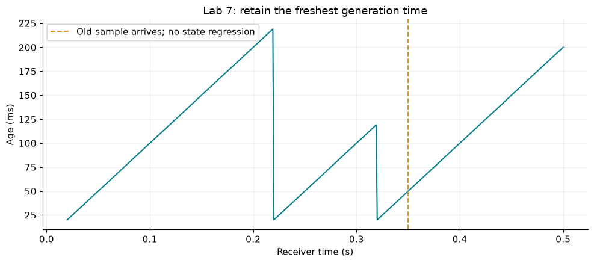

```python
generated=np.array([0.,.1,.2,.3])
delays=np.array([.02,.25,.02,.02])
arrived=generated+delays
order=np.argsort(arrived)
times=np.linspace(.02,.5,481)
latest=np.full_like(times,np.nan)
for i,t in enumerate(times):
    eligible=generated[arrived <= t+1e-12]
    if len(eligible): latest[i]=eligible.max()
age=times-latest
freshest=-np.inf; accepted=[]
for i in order:
    use=generated[i]>freshest
    accepted.append(use)
    if use: freshest=generated[i]
    print(f'Arrival {arrived[i]:.2f}s, generated {generated[i]:.2f}s: '+('advance latest state' if use else 'old reordered sample; history only'))
assert accepted == [True,True,True,False]
assert math.isclose(freshest,.3)
fig, ax=plt.subplots()
ax.plot(times,age*1000,color=TEAL)
ax.axvline(.35,color=GOLD,linestyle='--',label='Old sample arrives; no state regression')
ax.set(xlabel='Receiver time (s)',ylabel='Age (ms)',title='Lab 7: retain the freshest generation time')
ax.legend(); plt.tight_layout(); plt.show()
```

## Lab 8 — Quorum intersection, causal vectors and convergent counters

**Objective:** verify small mathematical properties without claiming a full distributed database. Enumerate all read/write sets for five replicas; compare vectors; check a grow-only counter merge.

**Method:** test intersections and algebraic merge laws on concrete states. **Expected result:** 3-of-5 read and write sets always intersect, while 2-of-5 reads can miss a 3-of-5 write. Counter merge is unchanged by order or duplicate inputs for the tested states. **Limit:** these checks do not model network failures, elections, concurrent transaction histories, durable logs or membership changes.

```
3-read / 3-write: every pair intersects.
2-read / 3-write counterexample: ((0, 1), (2, 3, 4))
Vectors (2, 1, 0) and (1, 2, 0) are concurrent in this fixed-vector model.
Merged G-counter: (4, 3, 5) value: 12 duplicate merge: (4, 3, 5)
```

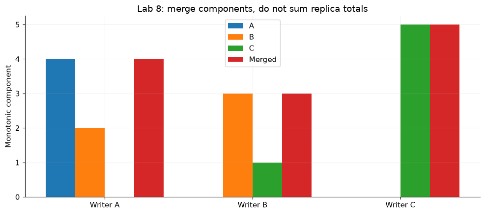

```python
replicas=range(5)
def disjoint_pairs(read_n,write_n):
    return [(r,w) for r in itertools.combinations(replicas,read_n)
            for w in itertools.combinations(replicas,write_n) if set(r).isdisjoint(w)]
assert not disjoint_pairs(3,3)
bad=disjoint_pairs(2,3)
assert bad
print('3-read / 3-write: every pair intersects.')
print('2-read / 3-write counterexample:',bad[0])
def merge(a,b): return tuple(max(x,y) for x,y in zip(a,b))
A,B,C=(4,0,0),(2,3,0),(0,1,5)
M=merge(merge(A,B),C)
assert M==(4,3,5) and sum(M)==12
assert merge(A,B)==merge(B,A)
assert merge(merge(A,B),C)==merge(A,merge(B,C))
assert merge(M,M)==M
def happens_before(a,b):
    return all(x<=y for x,y in zip(a,b)) and any(x<y for x,y in zip(a,b))
va,vb=(2,1,0),(1,2,0)
assert not happens_before(va,vb) and not happens_before(vb,va)
print('Vectors',va,'and',vb,'are concurrent in this fixed-vector model.')
print('Merged G-counter:',M,'value:',sum(M),'duplicate merge:',merge(M,A))
fig,ax=plt.subplots()
x=np.arange(3); width=.2
for j,(name,state) in enumerate([('A',A),('B',B),('C',C),('Merged',M)]):
    ax.bar(x+(j-1.5)*width,state,width,label=name)
ax.set(xticks=x,xticklabels=['Writer A','Writer B','Writer C'],ylabel='Monotonic component',
       title='Lab 8: merge components, do not sum replica totals')
ax.legend(); plt.tight_layout(); plt.show()
```

## Arithmetic verification — all 24 worked problems

This cell recomputes each main result from the chapter inputs. Assertions use tolerances where floating-point arithmetic is involved. They check calculation transcription, not the empirical validity of the hypothetical inputs.

```python
checks = [
 ('VANET contact, s',(300-100)/20,10),
 ('VANET beacon, Mbit/s',120*10*300*8/1e6,2.88),
 ('VANET path probability',.95*.90*.98,.8379),
 ('IoV ingress, Mbit/s',800*(1/.5)*250*8/1e6,3.2),
 ('IoV raw outage buffer, MB',50*400*90/1e6,1.8),
 ('IoV slack, ms',100-sum([8,4,15,20,12,6]),35),
 ('Edge remote time, s',8/20+.03+.05+2e9/1e10+.8/40,.7),
 ('Edge break-even, Mbit/s',8/(2-.3),4.705882352941177),
 ('Edge mean response at 90/s, ms',1000/(100-90),100),
 ('Fog outgoing, Mbit/s',20*2*.15,6),
 ('Fog parallel pipeline, ms',5+max(12,20)+4+6,35),
 ('Fog checkpoint, s',60*8/120+.2,4.2),
 ('Cloud daily payload, GB',1000*2*500*86400/1e9,86.4),
 ('Cloud unavailable time, min',(1-.999)*30*24*60,43.2),
 ('Cloud series availability',.999*.995*.999,.993010995),
 ('Middleware egress, Mbit/s',200*1000*8*6/1e6,9.6),
 ('Middleware drain, s',120/(80-50),4),
 ('Middleware unique effects',len(set(['a','b','a','c','b','d']))*10,40),
 ('Sync offset, s',((10.130-10)+(10.150-10.080))/2,.1),
 ('Sync resynchronization, s',(.002-.0002)/(2*20e-6),45),
 ('Sync motion bound, m',25*(12.120-12),3),
 ('Consistency majority failures',5-(5//2+1),2),
 ('Consistency vector result',tuple(list(merge((2,1,0),(1,2,0)))[:2]+[1]),(2,2,1)),
 ('Consistency counter value',sum(merge(merge((4,0,0),(2,3,0)),(0,1,5))),12),
]
for name, actual, expected in checks:
    if isinstance(expected,tuple): assert actual==expected,(name,actual)
    else: assert math.isclose(actual,expected,rel_tol=1e-10,abs_tol=1e-10),(name,actual)
    print(f'PASS | {name}: {actual}')
assert math.isclose((10.080-10)-(10.150-10.130),.06,abs_tol=1e-10)
assert math.isclose(1/(100-60),.025)
assert math.isclose(1.8*1.25,2.25)
assert math.isclose(86.4*3,259.2)
print(f'All {len(checks)} main worked-problem checks and supplementary checks passed.')
```

```
PASS | VANET contact, s: 10.0
PASS | VANET beacon, Mbit/s: 2.88
PASS | VANET path probability: 0.8379
PASS | IoV ingress, Mbit/s: 3.2
PASS | IoV raw outage buffer, MB: 1.8
PASS | IoV slack, ms: 35
PASS | Edge remote time, s: 0.7000000000000001
PASS | Edge break-even, Mbit/s: 4.705882352941177
PASS | Edge mean response at 90/s, ms: 100.0
PASS | Fog outgoing, Mbit/s: 6.0
PASS | Fog parallel pipeline, ms: 35
PASS | Fog checkpoint, s: 4.2
PASS | Cloud daily payload, GB: 86.4
PASS | Cloud unavailable time, min: 43.20000000000004
PASS | Cloud series availability: 0.993010995
PASS | Middleware egress, Mbit/s: 9.6
PASS | Middleware drain, s: 4.0
PASS | Middleware unique effects: 40
PASS | Sync offset, s: 0.10000000000000053
PASS | Sync resynchronization, s: 44.99999999999999
PASS | Sync motion bound, m: 2.9999999999999805
PASS | Consistency majority failures: 2
PASS | Consistency vector result: (2, 2, 1)
PASS | Consistency counter value: 12
All 24 main worked-problem checks and supplementary checks passed.
```

# Integrated design case — a connected autonomous campus shuttle

This is an **original hypothetical design study**, not an account of a deployed shuttle or a safety certification. It integrates every requested topic. All time and capacity targets below are teaching requirements selected for the exercise.

## Requirements before components

The shuttle publishes status, receives selected roadside observations and uploads diagnostic history. It retains a separately specified local operating capability during loss of remote services. The roadside observation service targets an observation-to-use budget of 100 ms in the exercise; expired observations must be explicitly rejected. Diagnostic history tolerates a 90 s outage within its provisioned buffer. A shared charging bay must not grant two overlapping valid reservations.

These requirements imply different communication and consistency policies. A universal “reliable, cloud-connected, real-time” label does not tell us what happens when a service is unavailable. The design must name the unavailable operation, retained capability and user-visible degraded state.

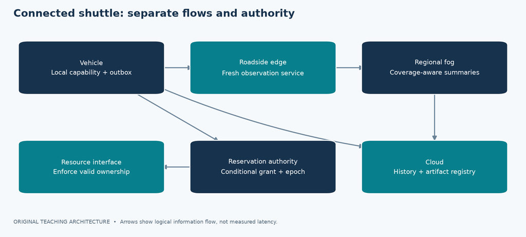

*Figure: Connected shuttle: separate flows and authority. Original conceptual diagram; see the surrounding text for assumptions.*

## Mapping all eight subjects

| Topic | Role in the proposed system | Concrete design artifact |
| --- | --- | --- |
| VANET | Local vehicle/roadside event exchange | Reachability and dissemination model |
| IoV | Identity, service lifecycle and fleet integration | Event schema and management path |
| Edge | Local observation processing | Admission and expiry-aware result path |
| Fog | Cross-intersection summaries | Coverage-aware aggregation contract |
| Cloud | Historical records and versioned artifacts | Durable ingestion and restore procedure |
| Middleware | Component communication | Per-stream QoS and schema rules |
| Synchronization | Time alignment and backlog transfer | Clock uncertainty and replay policy |
| Consistency | Reservation authority and shared-state rules | Atomic acquisition plus fencing |

## Data dictionary and invariants

**Observation record:** immutable ID, producer/boot identity, generation time, time uncertainty, coordinate frame, payload and expiry. Invariant: an expired record is never promoted to “current” merely because it has just arrived.

**Configuration bundle:** version ID, compatible schema/model versions, integrity metadata and activation state. Invariant: a consumer does not activate a partially received bundle or an incompatible combination.

**Reservation:** resource ID, owner, interval, operation ID and authority epoch. Invariant: the service does not issue overlapping valid grants for the same exclusive resource under its stated authority model; the resource interface enforces the accepted epoch.

**Diagnostic event:** immutable event ID and observation time. Invariant: retransmitting an existing ID does not create an additional logical event. Physical duplication in transport or storage can still exist; the logical count remains one.

## Normal sequence

```
Sensor    Vehicle app    Roadside edge    Regional service    Cloud
  | observe   |               |                 |              |
  |---------->| validate      |                 |              |
  |           |--selected---->| align + compute |              |
  |           |<--result------|                 |              |
  |           | age/epoch check                |              |
  |           |               |--summary------>|              |
  |           |               |                |--history---->|
  |           |--durable diagnostic upload------------------->|
  |           |<--acknowledged event IDs-----------------------|
```

This diagram contains independent flows. It does not require every observation to wait for a cloud acknowledgment before the vehicle's local function continues. The application contract determines which paths are prerequisites for which decisions.

## Failure-mode analysis

| Injected failure | Incorrect behavior to catch | Proposed observable response |
| --- | --- | --- |
| RSU link lost | Reuse stale scene indefinitely | Expire remote scene; expose missing coverage |
| Edge overload | Accept work that cannot meet expiry | Reject/degrade according to admission policy |
| Clock uncertainty rises | Fuse observations as if simultaneous | Reject temporal pairing or enlarge declared uncertainty |
| Duplicate upload | Double-count one diagnostic event | Return original event result |
| Old command after failover | Allow stale owner to act | Enforce epoch at resource boundary |
| Regional source absent | Treat missing interval as zero | Publish completeness/coverage metadata |
| Cloud acknowledgment lost | Invent a fresh ID for retry | Retry with the stable operation ID |
| Model transfer interrupted | Activate partial files | Keep prior compatible bundle active |

## Validation plan

Generate deterministic event traces, then vary delay, duplication, loss, reordering, reboot and partition. Measure observation age at use, deadline-miss fraction, duplicate logical effects, queue occupancy, missing-source coverage and recovery time. Include a worst observed case and the workload under which it occurred; do not call that observed maximum an absolute bound.

For the reservation path, check the invariant after every modeled transition, including lost replies and stale commands. For the history path, compare unique submitted IDs with unique recovered IDs. For the real-time path, examine expired-message rejection. These tests verify different properties and should not be merged into one vague “accuracy” metric.

**Critical assessment:** the design has more moving parts than a vehicle-plus-server prototype. A fog tier is justified only by the multi-intersection requirement; consensus is reserved for exclusive shared authority; raw data retention is bounded by the debugging need. Removing an unnecessary tier can reduce both cost and failure modes. A rigorous architecture explains why each component exists.

# Documented research case — Spanner and the meaning of time

The 2012 Spanner paper reports a globally distributed database design using a time API that exposes uncertainty, combined with replication and transaction mechanisms to provide external consistency. This is a documented systems-research example, not a vehicular deployment example. [S19](https://www.usenix.org/conference/osdi12/technical-sessions/presentation/corbett)

**Teaching relevance:** physical time quality and ordering mechanisms can be designed together. A scalar timestamp alone does not provide this result. The important question for an autonomous application is which operations require a globally ordered outcome and what delay or unavailability the application can tolerate.

**Limit of transfer:** this paper does not establish a latency bound for our hypothetical shuttle, nor prove that its database architecture should be copied into an on-board control loop. We use the case to challenge the false claim that wall-clock timestamps automatically make replicas consistent. The notebook's labs do not implement Spanner.

# Examination preparation — questions with developed answers

## VANETs

**Question:** Explain VANET architecture and the effect of mobility on communication.

**Answer:** Draw vehicles with OBUs, an RSU, an optional backhaul path and a remote application. Label V2V and V2I separately. Explain that a communication link is time-dependent, so a route must survive long enough to deliver the relevant data. A local warning and a historical upload have different expiry requirements. Discuss sparse connectivity, dense offered traffic, duplicate suppression and the chosen forwarding approach. Define delivery ratio and its intended receiver population, then add delay or age and routing overhead. Finish with a link-loss example and an explicit fallback; naming radio technologies alone is not an architecture explanation. See Chapter 1 and its cited ETSI/AODV sources.

**Question:** Why is maximum throughput an inadequate objective for a hazard-warning network?

**Answer:** Throughput counts delivered bits per unit time; it does not state whether a relevant vehicle received a particular warning before expiry. A network could deliver many large low-priority records while delaying an urgent small event. A warning evaluation should define intended receivers, spatial relevance, expiry, useful delivery probability and maximum inter-reception gaps. Include duplicate and security-processing costs. The beacon numerical also shows why payload load is not equivalent to channel busy ratio. This is a metric-selection argument based on the chapter's application model.

## Internet of Vehicles

**Question:** Distinguish VANET and IoV with a suitable example.

**Answer:** VANET emphasizes communication among moving vehicular participants and roadside nodes. IoV, as defined in this book, includes the wider service lifecycle: identity, data contracts, computing, history and management. In the bus example, local road-event exchange belongs to the networking layer, while depot reconciliation, model distribution and maintenance history belong to the broader service architecture. The two terms therefore describe related scopes rather than mutually exclusive systems. Draw one communication path and one management path to make the distinction concrete.

**Question:** Design a telemetry envelope that survives disconnection and reboot.

**Answer:** Include stable event identity, producer identity, boot epoch, sequence number, observation time, uncertainty, schema version and payload units. Keep ingestion time separately. On reconnection, retry the same logical event ID; on reboot, change the epoch so a sequence reset does not collide with an old stream. Report unavailable fields as unknown rather than zero. Explain receiver validation and deduplication, then distinguish replayed historical data from current state. This is the original data contract developed in Chapter 2.

## Edge computing

**Question:** Derive the offloading condition and explain why a faster server may not help.

**Answer:** Start from local compute time $C/f_l$. Add upload, fixed overhead, queueing, remote compute and download for remote time. Offloading is faster only when the sum is smaller, and feasible only when it also meets the deadline and resource constraints. Isolate uplink time to obtain $R_u>B_u/(T_l-T_r)$ when $T_l>T_r$. If the non-upload remote remainder already exceeds local time, unlimited uplink bandwidth cannot solve the problem. Mention mobility contact duration and device versus infrastructure energy boundaries.

**Question:** How should an edge server behave under overload?

**Answer:** First classify data semantics. For replaceable state, discard or overwrite obsolete queued samples under a declared policy. For durable events, buffer within a bounded capacity, apply backpressure or reject explicitly. Admit deadline-constrained tasks only when the scheduler's model supports completion. Measure queue age as well as queue length. A QoS label cannot create missing processing capacity. Explain that a mean M/M/1 result is useful for intuition but not a deterministic deadline guarantee.

## Fog computing

**Question:** Compare hierarchical and federated fog designs.

**Answer:** A hierarchy moves local summaries through regional aggregation toward broader services, simplifying parent-child responsibilities. Federation allows selected peer or cross-domain cooperation but requires compatible identity, schema and resource agreements. In either arrangement, account for data lost through aggregation, common failure domains and ownership of mutable state. Draw the task dependency graph and distinguish serial from parallel branches. The best topology follows information and operational requirements rather than an obligation to include every layer.

**Question:** Explain why a missing sensor cannot automatically contribute zero to an aggregate.

**Answer:** Zero is a measured value; missing is absence of evidence. If one intersection disconnects, summing only received counts can make traffic appear lower while actual traffic is unchanged. Attach source and interval IDs, publish completeness metadata, and apply a declared late-data policy. If estimation is used to fill gaps, label estimates and propagate their uncertainty. The corridor case makes these semantics explicit instead of hiding them in a dashboard total.

## Cloud architectures

**Question:** Explain service models, deployment models and a fleet backend architecture.

**Answer:** Separate IaaS/PaaS/SaaS from public/private/community/hybrid deployment choices, as defined by NIST. Then draw authenticated ingestion, durable events, stream processing, operational state, historical storage and analytics. Define precisely what an acknowledgment means. Calculate ingress and retention from producer rates, then account separately for copies and indexing. Explain replay and restore behavior. A good answer does not equate cloud computing with a single remote machine or claim that a provider automatically satisfies the application's recovery objectives.

**Question:** Distinguish replication, partitioning and backup.

**Answer:** Replication maintains copies of the same logical data; partitioning divides ownership across data subsets; backup preserves a recoverable historical state. Replication can copy an erroneous deletion, so it cannot substitute for every backup purpose. Partitioning may spread load but leaves hot-key and cross-partition coordination questions. Describe a failure each technique addresses and one it does not. Add RPO/RTO requirements and a restore verification procedure rather than treating redundant storage as proof of recovery.

## Middleware

**Question:** Compare DDS/ROS 2, MQTT and CoAP without mixing abstraction levels.

**Answer:** Identify ROS 2 as an application framework, DDS as data-distribution middleware, MQTT as a brokered publish/subscribe transport and base CoAP as a constrained resource protocol. Then compare the actual interaction needed: typed local streams, fleet telemetry or device resource operations. Discuss compatibility, buffering, expiry, discovery, retry behavior and tooling. The comparison must state editions and implementation assumptions before making performance claims. Chapters 6 and the linked specifications provide the protocol basis.

**Question:** Does MQTT QoS 2 guarantee exactly one physical action?

**Answer:** No such application guarantee follows solely from the protocol setting. Distinguish message delivery from consumer processing and actuator execution. A consumer may crash after applying an effect but before recording completion; a retry can then repeat it unless the application coordinates identity and state appropriately. For a database effect, an atomic deduplication pattern can help. For physical actions outside that transaction, design command state, feedback and reconciliation. The exact boundary of the guarantee must be named.

## Synchronization

**Question:** Compare physical time, Lamport time and vector time.

**Answer:** Physical time relates timestamps to elapsed or reference time with uncertainty. Lamport counters preserve happened-before ordering in one direction but do not measure seconds or fully identify concurrency. Vector clocks in the fixed-participant model retain per-participant history and allow a componentwise concurrency comparison, at higher metadata cost. Give one NTP calculation, one send/receive Lamport update and one pair of incomparable vectors. Explain that synchronized clocks do not imply synchronized replicas.

**Question:** Why can a system have high delivery ratio and poor freshness?

**Answer:** Packets can all arrive after waiting in a long queue. Delivery ratio ignores when their observations were generated. Define age at consumption, preserve observation timestamps, and prevent a reordered old packet from replacing newer state. Use expiry and appropriate queue policies for latest-state consumers. Analyze a reconnecting device separately: historical replay may be valuable for logs but should not become a fresh control observation. The synchronization lab plots both generation and arrival effects.

## Distributed consistency

**Question:** Explain CAP using an execution rather than “pick two.”

**Answer:** Partition two replicas initialized with the same value. Complete a write on one side, then issue a read on the other. The isolated reader cannot know the new value. Requiring a valid reply from the old state can violate atomic consistency, while waiting indefinitely violates the formal availability condition. Explain why uptime percentages are a different measure. Then choose a partition policy for a particular operation, such as refusing an exclusive reservation while still buffering telemetry. See Chapter 8 and Gilbert–Lynch.

**Question:** Compare consensus and CRDT approaches for a shared resource.

**Answer:** A coordinated state machine can serialize conditional grants under its stated fault assumptions, with reduced availability when authority cannot be established. A suitable CRDT supports convergent updates without the same per-update coordination, but its permitted operations and merge rules must preserve the required semantics. A grow-only activity counter is a useful example; an exclusive physical bay cannot be made safe by merging conflicting grants after entry. Discuss epochs and enforcement at the resource interface. Neither convergence nor agreement alone proves physical safety.

# Practice problems and answer guide

Attempt these before reading the guide. Every number is hypothetical.

| Topic | Practice problem | Answer guide |
| --- | --- | --- |
| VANET | Separation is 80 m, range 240 m, receding speed 16 m/s. Find remaining contact. | $(240-80)/16=10$ s under constant linear motion. |
| IoV | 200 producers send 600 bytes at 5 Hz. Find payload bit rate. | $200\times600\times5\times8=4.8$ Mbit/s. |
| Edge | Local time 0.8 s, remote non-upload cost 0.3 s, input 5 Mbit. Find break-even uplink. | $5/(0.8-0.3)=10$ Mbit/s. |
| Fog | Raw aggregate 75 Mbit/s, retained fraction 0.2. Find output and reduction. | 15 Mbit/s and 80% reduction. |
| Cloud | 0.5 MB/s raw payload for 7 days, two copies. Find copied decimal GB. | $0.5\times604800\times2/1000=604.8$ GB. |
| Middleware | Queue 180 records, input 40/s, service 100/s. Find fluid drain time. | $180/(100-40)=3$ s. |
| Synchronization | Pairwise initial uncertainty 0.1 ms, two 10 ppm drift bounds, 1 ms limit. | $(0.001-0.0001)/(20\times10^{-6})=45$ s. |
| Consistency | Seven replicas with reads of four and writes of four. Check overlap and majority failure tolerance. | $4+4>7$; majority four; three crashes leave progress possible. |

### Design exercises with marking criteria

**Exercise:** Redesign the campus system without a fog tier. **Expected reasoning:** identify which cross-intersection function moves elsewhere, calculate the altered path and traffic, discuss operational simplification, and state which requirement could fail. A diagram alone is insufficient.

**Exercise:** Replace latest-state queues with reliable FIFO everywhere. **Expected reasoning:** construct an overload trace, calculate age at use, explain memory limits and distinguish recoverable history from obsolete state. Do not assume “reliable” means “timely.”

**Exercise:** Allow each partition to reserve the same charging bay. **Expected reasoning:** construct two successful grants, show the invariant violation, and propose refusal, preallocated disjoint rights or another explicit authority design. A last-writer-wins merge after physical entry does not resolve the original conflict.

**Exercise:** Evaluate a claim of 90% bandwidth saving from aggregation. **Expected reasoning:** request input/output definitions, workload, overhead accounting, accuracy/information-loss effect and a baseline. Recompute the ratio and state whether the same application requirement is met.

# Formula sheet and common misconceptions

| Quantity | Formula | Key condition |
| --- | --- | --- |
| Transmission delay | $L/R$ | Bits and bit/s; effective rate defined |
| Remaining range contact | $(R-d_0)/v_{rel}$ | Receding straight-line constant motion |
| Payload generation | $nrb\times8$ | $b$ in bytes |
| Local compute | $C/f$ | Effective processing rate model |
| Offload time | $B_u/R_u+T_o+T_q+C/f_e+B_d/R_d$ | Sequential model |
| M/M/1 mean response | $1/(\mu-\lambda)$ | Model assumptions and stability |
| Fluid backlog drain | $B/(\mu-\lambda)$ | Net service positive; consistent units |
| Stored payload | Rate × retention | Explicit copies/overhead separately |
| Series availability | $\prod_i A_i$ | Independent required components |
| Clock offset estimate | $[(t_2-t_1)+(t_3-t_4)]/2$ | Symmetry for exact interpretation |
| Relative drift bound | $\epsilon_0+2\rho T$ | Two bounded clocks |
| Data age | $t-u(t)$ | Comparable time reference |
| Read/write overlap | $R_q+W_q>N$ | Fixed replica universe |
| Majority | $\lfloor N/2\rfloor+1$ | Crash-fault majority setting |
| G-counter merge | componentwise max | Per-writer monotonic components |

**Incorrect:** edge is always faster. **Correction:** include upload, queueing and return cost.

**Incorrect:** fog is simply a smaller cloud. **Correction:** explain its distributed intermediate coordination role in the chosen architecture.

**Incorrect:** a received packet is useful forever. **Correction:** define generation time, uncertainty and expiry.

**Incorrect:** a reliable protocol guarantees a deadline. **Correction:** delivery policy and bounded completion are different properties.

**Incorrect:** replicated data is backed up. **Correction:** a replica may reproduce corruption or deletion.

**Incorrect:** scalar logical timestamps measure elapsed time. **Correction:** they encode an order relation.

**Incorrect:** quorum overlap proves every database property. **Correction:** it is one set-intersection condition within a larger protocol.

**Incorrect:** consistent state guarantees safe physical action. **Correction:** application invariants, sensor validity, timing and resource enforcement remain necessary.

# Glossary

| Term | Meaning used in this book |
| --- | --- |
| Actuation | Applying a physical command through an interface |
| Admission control | Deciding whether to accept work under resource/semantic constraints |
| Age of information | Elapsed time since generation of the latest usable observation |
| Anti-entropy | Reconciliation that discovers and repairs replica differences |
| Backhaul | Connectivity from a local/access site toward broader network services |
| Backpressure | Signaling or applying a reduction of upstream production/admission |
| Causal dependency | An event's dependence through process order or communication |
| Checkpoint | State image associated with a defined recovery/log boundary |
| Consistency contract | Rules for permitted observations of shared state |
| CRDT | Replicated data type with specified convergence-preserving operations |
| Deadline | Latest permitted completion time for a stated operation |
| Deduplication | Recognizing repeated identities to avoid duplicate logical processing |
| Edge host | Compute resource near a specified source or point of use |
| Epoch | Generation identifier used to distinguish ownership or reboot periods |
| Event time | Time associated with the originating observation or event |
| Failure domain | Components susceptible to a stated common failure cause |
| Fencing token | Ordered authority token enforced by a resource |
| Fog federation | Cooperation among intermediate computing resources/domains |
| Idempotency | Repeating an operation has the same intended state effect as one application |
| Ingestion time | Time at which a receiving system accepts an event |
| Invariant | Property required to remain true across allowed transitions |
| Jitter | Variation in delay or timing under a declared definition |
| Linearizability | Atomic object behavior respecting real-time precedence |
| Liveness | Progress property under stated assumptions |
| Middleware | Integration and communication facilities between applications and lower layers |
| OBU | On-board communication unit in the reference architecture |
| Partition | Communication separation between portions of a distributed system |
| Provenance | Information describing origin and transformation of data |
| Quorum | A required participating subset for a protocol operation |
| Replica | Copy of some logical state maintained at a participant |
| RPO | Recovery-point objective for acceptable data loss |
| RTO | Recovery-time objective for restoration |
| RSU | Roadside communication unit in the reference architecture |
| Safety property | A requirement that an undesirable state never occurs in the model |
| Schema | Definition of data fields, types and interpretation |
| Sidelink | Direct communication interface discussed in cellular V2X |
| Staleness | Difference between available information and a specified freshness reference |
| Telemetry | Reported operational observations or measurements |
| Vector clock | Per-participant logical-history vector in the fixed-set model |
| V2X | Vehicle-to-everything communication umbrella terminology |

For formal definitions and edition-specific details, use the chapter references; the glossary is a concise study aid rather than a replacement for the cited standards.

# References and verification boundaries

Sources were checked on **24 September 2026**. Primary standards, official documentation and original research are used. Older foundational publications remain identified by their actual year; this notebook does not call them newly published or claim every cited edition is the latest. The notes are original instructional synthesis, and the numerical data, diagrams, labs and design cases are authored examples.

[output not shown]

## What has and has not been validated

The delivered notebook is executed locally. Its executable examples assert selected arithmetic results and demonstrate the stated toy models. Embedded figures are generated from original diagram specifications. Execution confirms that the examples run and their programmed checks pass; it does not validate a real VANET radio, middleware deployment, cloud SLA, autonomous controller or consensus implementation.

The case studies identify the evidence a real evaluation would need rather than inventing accuracy, latency or safety results. Jurisdiction-specific radio permissions, product pricing and deployment certification are outside the supplied topic list and are not asserted. If you adapt these notes for a specific syllabus, add its prescribed protocol editions and learning outcomes rather than assuming this topic-based book is identical to that syllabus.